# Mortgage Collateral Risk Deep-Learning Assistant

**Course:** Advanced Machine Learning — Final Project  
**Task:** Image Analysis with CNNs and Text Analysis with RNNs  
**Domain:** Real Estate / Mortgage Collateral Underwriting

## Business Problem

A mortgage underwriter or P2P-lending platform receives a property listing (photo + description) as collateral for a loan application. Manually assessing every listing's visual quality and description accuracy is slow and inconsistent. This project builds two specialised deep-learning models that automate the assessment:

- **CNN branch** — classifies a property photo into a **price band** (Budget / Economy / Mid-Range / Premium / Luxury), indicating the visual quality tier of the collateral.
- **RNN/LSTM branch** — classifies a property listing description into the same price band, capturing textual signals of value (amenities, condition language, neighbourhood cues).
- **Business integration** — a decision rule combines both predictions against the applicant's *claimed* value band to flag collateral risk: `LOW` (auto-proceed), `MEDIUM` (secondary review), or `HIGH` (manual appraisal required).
- **Joint model (+10 bonus)** — a single network consuming both image and text features predicts the price band end-to-end, benchmarked against each unimodal model.

**End user:** Mortgage underwriter / risk officer.  
**FP cost:** Unnecessary manual appraisal (operational overhead).  
**FN cost:** Over-lending on over-valued collateral (credit loss).

## Team Contribution Table

| Member | Sections |
| --- | --- |
| Raivo Strods | All sections (individual project) |

## 1. Setup and Reproducibility

```python
import warnings
warnings.filterwarnings('ignore')

import os
import random
import json
import re
import math
import io
import zipfile
import shutil
from pathlib import Path
from collections import Counter

import numpy as np
import pandas as pd
import matplotlib.pyplot as plt
import matplotlib.image as mpimg
import seaborn as sns
from PIL import Image
from wordcloud import WordCloud

import torch
import torch.nn as nn
import torch.optim as optim
import torch.nn.functional as F
from torch.utils.data import Dataset, DataLoader, WeightedRandomSampler
import torchvision
import torchvision.transforms as transforms
import torchvision.models as models
from torchvision.datasets import ImageFolder

from sklearn.model_selection import train_test_split
from sklearn.metrics import (
    accuracy_score, f1_score, classification_report,
    confusion_matrix, ConfusionMatrixDisplay
)

sns.set_theme(style='whitegrid', palette='colorblind', font_scale=1.1)
pd.set_option('display.max_columns', 30)
pd.set_option('display.max_colwidth', 120)

RANDOM_STATE = 42
DEVICE = torch.device('cuda' if torch.cuda.is_available() else 'cpu')

def seed_everything(seed=RANDOM_STATE):
    random.seed(seed)
    np.random.seed(seed)
    torch.manual_seed(seed)
    torch.cuda.manual_seed_all(seed)
    torch.backends.cudnn.deterministic = True
    torch.backends.cudnn.benchmark = False

seed_everything()
print(f'Device: {DEVICE}')
print(f'PyTorch: {torch.__version__}')
print(f'Torchvision: {torchvision.__version__}')
print('All imports successful.')
```

```
Device: cuda
PyTorch: 2.6.0+cu124
Torchvision: 0.21.0+cu124
All imports successful.
```

```python
DATA_DIR = Path('data')
IMAGE_DIR = DATA_DIR / 'images'
MODEL_DIR = Path('models')
MODEL_DIR.mkdir(exist_ok=True)
DATA_DIR.mkdir(exist_ok=True)

BAND_NAMES = ['Budget', 'Economy', 'Mid-Range', 'Premium', 'Luxury']
NUM_CLASSES = len(BAND_NAMES)
IMG_SIZE = 224
BATCH_SIZE = 32
# Windows + Jupyter: DataLoader worker subprocesses cannot re-import classes
# defined in the notebook, so we load on the main thread (0 workers).
NUM_WORKERS = 0
```

## 2. Data Loading

### Dataset strategy

Both datasets are from the real-estate / property valuation domain. We derive the **same 5-class ordinal target** (price band from quantiles) independently for each dataset.

For the **joint model (+10 bonus)**, we use the Airbnb NYC dataset which contains both `picture_url` (downloadable property images) and `description` (rich text) with `price` for the same listing — providing naturally paired image+text+label samples.

**Instructions for downloading the datasets:**

Option A — Using the Kaggle CLI:

```
pip install kaggle
# Place your kaggle.json API token in ~/.kaggle/
kaggle datasets download -d ted8080/house-prices-and-images-socal -p data/
kaggle datasets download -d kanchana1990/real-estate-data-london-2024 -p data/
kaggle datasets download -d arianazmoudeh/airbnbopendata -p data/
```

Option B — Manual download from Kaggle and extract into the `data/` folder.

The cell below attempts the Kaggle CLI download. If the API token is not configured, download manually.

```python
# Attempt Kaggle download — skip gracefully if API key not configured or data already present
import subprocess, sys, shutil

datasets = [
    # (kaggle slug, sentinel file/dir that indicates the dataset is already extracted)
    ('ted8080/house-prices-and-images-socal', 'socal2.csv'),
    ('kanchana1990/real-estate-data-london-2024', 'realestate_data_london_2024_nov.csv'),
    ('arianazmoudeh/airbnbopendata', 'Airbnb_Open_Data.csv'),
]

def _have_kaggle_cli():
    return shutil.which('kaggle') is not None

for ds, sentinel in datasets:
    sentinel_path = DATA_DIR / sentinel
    if sentinel_path.exists():
        print(f'Already present: {sentinel}')
        continue
    if not _have_kaggle_cli():
        print(f'Skipping {ds}: kaggle CLI not found. '
              f'Install with `pip install kaggle` and configure ~/.kaggle/kaggle.json')
        continue
    try:
        subprocess.run(
            ['kaggle', 'datasets', 'download', '-d', ds, '-p', str(DATA_DIR), '--unzip'],
            check=True, capture_output=True, text=True, timeout=600,
        )
        print(f'Downloaded: {ds}')
    except Exception as e:
        print(f'Could not auto-download {ds}: {e}')
        print('Please download manually from Kaggle and extract into data/')

print('\nContents of data/:')
for p in sorted(DATA_DIR.iterdir()):
    if p.is_dir():
        n = sum(1 for _ in p.rglob('*') if _.is_file())
        print(f'  {p.name}/ ({n} files)')
    else:
        print(f'  {p.name} ({p.stat().st_size / 1e6:.1f} MB)')
```

```
Already present: socal2.csv
Already present: realestate_data_london_2024_nov.csv
Already present: Airbnb_Open_Data.csv

Contents of data/:
  Airbnb_Open_Data.csv (35.9 MB)
  glove.6B.100d.txt (347.1 MB)
  realestate_data_london_2024_nov.csv (1.9 MB)
```

```
  socal2/ (15474 files)
  socal2.csv (1.0 MB)
```

### 2.1 Load Image Dataset (SoCal Houses)

```python
# The SoCal dataset has images in folders and a CSV mapping image -> price
# Adapt path to actual extracted structure
socal_csv_candidates = list(DATA_DIR.rglob('*.csv'))
print('CSV files found:', [str(p) for p in socal_csv_candidates])

# Load the main CSV that maps images to prices
socal_csv = None
for f in socal_csv_candidates:
    df_tmp = pd.read_csv(f, nrows=5)
    cols_lower = [c.lower() for c in df_tmp.columns]
    if any('price' in c for c in cols_lower) and any('image' in c or 'img' in c or 'file' in c or 'path' in c for c in cols_lower):
        socal_csv = f
        break

if socal_csv is None:
    # Try finding image folders with numeric price-based folder names
    img_dirs = [d for d in DATA_DIR.rglob('*') if d.is_dir() and list(d.glob('*.jpg'))]
    print(f'Image directories found: {len(img_dirs)}')
    if img_dirs:
        print('Sample dirs:', [d.name for d in img_dirs[:5]])

# For SoCal dataset: images are typically in folders named by price or with a mapping CSV
# We'll handle both structures
all_image_files = sorted(DATA_DIR.rglob('*.jpg')) + sorted(DATA_DIR.rglob('*.jpeg')) + sorted(DATA_DIR.rglob('*.png'))
print(f'\nTotal image files found: {len(all_image_files)}')
if all_image_files:
    print(f'Sample paths: {[str(p) for p in all_image_files[:3]]}')
```

```
CSV files found:
```

```
 ['data\\Airbnb_Open_Data.csv', 'data\\realestate_data_london_2024_nov.csv', 'data\\socal2.csv']

Total image files found: 15474
Sample paths: ['data\\socal2\\socal_pics\\0.jpg', 'data\\socal2\\socal_pics\\1.jpg', 'data\\socal2\\socal_pics\\10.jpg']
```

```python
# Build the image dataframe with file paths and prices
# Structure depends on extracted dataset — adapt as needed

def build_image_dataframe(data_dir):
    """Build a DataFrame of (image_path, price) from the SoCal dataset.

    Handles multiple possible directory structures:
    1. CSV with image paths and prices
    2. Folders named by price range
    3. Images with price encoded in filename or parent folder
    """
    records = []

    # Strategy 1: Look for a CSV mapping
    for csv_file in data_dir.rglob('*.csv'):
        try:
            df = pd.read_csv(csv_file)
            price_col = next((c for c in df.columns if 'price' in c.lower()), None)
            if price_col is None:
                continue
            # Find image path column or construct from other columns
            img_col = next((c for c in df.columns if any(k in c.lower() for k in ['image', 'img', 'file', 'path', 'photo']) and not c.lower().endswith('_id') and c.lower() != 'image_id'), None)
            if img_col:
                for _, row in df.iterrows():
                    img_path = data_dir / str(row[img_col])
                    if img_path.exists():
                        records.append({'image_path': str(img_path), 'price': float(row[price_col])})
            else:
                # Try to match by index or ID
                id_col = next((c for c in df.columns if any(k in c.lower() for k in ['id', 'index', 'zpid'])), None)
                if id_col:
                    all_imgs = {p.stem: p for p in data_dir.rglob('*.jpg')}
                    all_imgs.update({p.stem: p for p in data_dir.rglob('*.png')})
                    for _, row in df.iterrows():
                        key = str(row[id_col])
                        if key in all_imgs:
                            records.append({'image_path': str(all_imgs[key]), 'price': float(row[price_col])})
            if records:
                print(f'Loaded {len(records)} image-price pairs from {csv_file.name}')
                break
        except Exception:
            continue

    # Strategy 2: If CSV didn't work, try folder-based structure
    if not records:
        for img_file in list(data_dir.rglob('*.jpg')) + list(data_dir.rglob('*.png')):
            parent = img_file.parent.name
            try:
                price = float(parent.replace(',', '').replace('$', ''))
                records.append({'image_path': str(img_file), 'price': price})
            except ValueError:
                # Try extracting price from filename
                match = re.search(r'(\d{4,})', img_file.stem)
                if match:
                    records.append({'image_path': str(img_file), 'price': float(match.group(1))})

    if not records:
        raise FileNotFoundError(
            'Could not build image-price mapping. '
            'Please check that the SoCal dataset is extracted correctly in data/'
        )

    return pd.DataFrame(records)

df_images = build_image_dataframe(DATA_DIR)
print(f'Image dataset: {len(df_images)} samples')
print(f'Price range: ${df_images["price"].min():,.0f} — ${df_images["price"].max():,.0f}')
df_images.head()
```

```
Loaded 15474 image-price pairs from socal2.csv
Image dataset: 15474 samples
Price range: $195,000 — $2,000,000
```

|  | image_path | price |
| --- | --- | --- |
| 0 | data\socal2\socal_pics\0.jpg | 201900.0 |
| 1 | data\socal2\socal_pics\1.jpg | 228500.0 |
| 2 | data\socal2\socal_pics\2.jpg | 273950.0 |
| 3 | data\socal2\socal_pics\3.jpg | 350000.0 |
| 4 | data\socal2\socal_pics\4.jpg | 385100.0 |

```python
# Create 5 price bands from quantiles
def assign_price_bands(df, price_col='price', n_bands=5):
    """Bin prices into ordinal bands using quantiles."""
    df = df.copy()
    df['price_band'], bin_edges = pd.qcut(
        df[price_col], q=n_bands, labels=BAND_NAMES, retbins=True, duplicates='drop'
    )
    df['price_band_id'] = df['price_band'].cat.codes
    print('Price band edges:')
    for i, name in enumerate(BAND_NAMES):
        if i < len(bin_edges) - 1:
            print(f'  {name}: ${bin_edges[i]:,.0f} — ${bin_edges[i+1]:,.0f}')
    return df, bin_edges

df_images, img_bin_edges = assign_price_bands(df_images)
print(f'\nClass distribution:\n{df_images["price_band"].value_counts().sort_index()}')
```

```
Price band edges:
  Budget: $195,000 — $399,000
  Economy: $399,000 — $555,000
  Mid-Range: $555,000 — $699,900
  Premium: $699,900 — $899,000
  Luxury: $899,000 — $2,000,000

Class distribution:
price_band
Budget       3177
Economy      3036
Mid-Range    3115
Premium      3060
Luxury       3086
Name: count, dtype: int64
```

### 2.2 Load Text Dataset (Real Estate Descriptions)

```python
# Load the London Real Estate text dataset
# Prefer the London dataset (rich HTML descriptions) over Airbnb (short listing names).
PREFERRED_TEXT_FILES = ['realestate_data_london_2024_nov.csv']

def load_text_dataset(data_dir):
    """Load a text dataset with property descriptions and prices.

    Tries preferred file names first, then falls back to any CSV with
    description + price columns. Uses latin-1 encoding to preserve
    currency symbols (£, €) that are not pure ASCII.
    """
    candidates = []
    for name in PREFERRED_TEXT_FILES:
        p = data_dir / name
        if p.exists():
            candidates.append(p)
    for p in sorted(data_dir.rglob('*.csv')):
        if p not in candidates:
            candidates.append(p)

    for csv_file in candidates:
        for enc in ('latin-1', 'utf-8'):
            try:
                df_full = pd.read_csv(csv_file, encoding=enc)
                desc_col = next(
                    (c for c in df_full.columns
                     if any(k in c.lower() for k in ['description', 'desc', 'summary'])),
                    None,
                )
                price_col = next((c for c in df_full.columns if 'price' in c.lower()), None)
                if desc_col is None or price_col is None:
                    break
                print(f'Loaded text data from {csv_file.name} (encoding={enc}): {len(df_full)} rows')
                print(f'Description column: {desc_col}')
                print(f'Price column: {price_col}')
                return df_full, desc_col, price_col
            except UnicodeDecodeError:
                continue
            except Exception:
                break
    raise FileNotFoundError('No text dataset with descriptions + prices found in data/')

df_text_raw, TEXT_DESC_COL, TEXT_PRICE_COL = load_text_dataset(DATA_DIR)
print(f'\nRaw text dataset shape: {df_text_raw.shape}')
df_text_raw.head(3)
```

```
Loaded text data from realestate_data_london_2024_nov.csv (encoding=latin-1): 1019 rows
Description column: descriptionHtml
Price column: price

Raw text dataset shape: (1019, 9)
```

|  | ï»¿"addedOn" | title | descriptionHtml | propertyType | sizeSqFeetMax | bedrooms | bathrooms | listingUpdateReason | price |
| --- | --- | --- | --- | --- | --- | --- | --- | --- | --- |
| 0 | 10/10/2024 | 8 bedroom house for sale in Winnington Road, Hampstead, London, N2, United Kingdom, N2 | This magnificent home, set behind security gates in one of the areaâs most coveted locations, has direct access to... | House | 16749.0 | 8.0 | 8.0 | new | £24,950,000 |
| 1 | Reduced on 24/10/2024 | 7 bedroom house for sale in Brick Street, Mayfair, London, W1J | In the heart of exclusive Mayfair, this majestic and luxurious Grade II listed property provides unique lateral livi... | House | 12960.0 | 7.0 | 7.0 | price_reduced | £29,500,000 |
| 2 | Reduced on 22/02/2024 | 6 bedroom terraced house for sale in Chester Square, SW1W | A freehold home that gives you everything you could want from a Belgravia sanctuary. That means a high-specification... | Terraced | 6952.0 | 6.0 | 6.0 | price_reduced | £25,000,000 |

```python
# Clean the text dataset
def clean_text_data(df, desc_col, price_col):
    """Clean descriptions and prices.

    Price cleaning uses a universal regex that strips anything that is not a
    digit or decimal point, so it works with any currency symbol and any
    source encoding (£, €, $, commas, whitespace, etc.).
    """
    df = df.copy()

    df[desc_col] = df[desc_col].astype(str)
    df[desc_col] = df[desc_col].str.replace(r'<[^>]+>', ' ', regex=True)
    df[desc_col] = df[desc_col].str.replace(r'\s+', ' ', regex=True).str.strip()

    df[price_col] = df[price_col].astype(str).str.replace(r'[^\d.]', '', regex=True)
    df[price_col] = pd.to_numeric(df[price_col], errors='coerce')

    before = len(df)
    df = df.dropna(subset=[desc_col, price_col])
    df = df[df[price_col] > 0]

    df['word_count'] = df[desc_col].str.split().str.len()
    df = df[df['word_count'] >= 15]

    q01, q99 = df[price_col].quantile([0.01, 0.99])
    df = df[(df[price_col] >= q01) & (df[price_col] <= q99)]

    print(f'Cleaned: {before} -> {len(df)} samples (after dropping short texts, missing prices, outliers)')
    print(f'Word count stats: mean={df["word_count"].mean():.0f}, '
          f'median={df["word_count"].median():.0f}, min={df["word_count"].min()}')
    return df.reset_index(drop=True)

df_text = clean_text_data(df_text_raw, TEXT_DESC_COL, TEXT_PRICE_COL)
df_text, txt_bin_edges = assign_price_bands(df_text, price_col=TEXT_PRICE_COL)
print(f'\nText dataset class distribution:\n{df_text["price_band"].value_counts().sort_index()}')
```

```
Cleaned: 1019 -> 996 samples (after dropping short texts, missing prices, outliers)
Word count stats: mean=252, median=224, min=18
Price band edges:
  Budget: $525,000 — $7,250,000
  Economy: $7,250,000 — $8,500,000
  Mid-Range: $8,500,000 — $10,000,000
  Premium: $10,000,000 — $14,500,000
  Luxury: $14,500,000 — $32,000,000

Text dataset class distribution:
price_band
Budget       211
Economy      218
Mid-Range    181
Premium      187
Luxury       199
Name: count, dtype: int64
```

## 3. Exploratory Data Analysis (EDA)

### 3.1 Image EDA

[figure not shown]

```python
# Display 20 sample images with labels (4 per price band, 5 rows)
fig, axes = plt.subplots(NUM_CLASSES, 4, figsize=(16, 4 * NUM_CLASSES))
fig.suptitle('Sample Property Images by Price Band', fontsize=16, fontweight='bold')

for ax_row, band in zip(axes, BAND_NAMES):
    subset = df_images[df_images['price_band'] == band]
    samples = subset.sample(min(4, len(subset)), random_state=RANDOM_STATE)
    for a, (_, row) in zip(ax_row, samples.iterrows()):
        try:
            img = Image.open(row['image_path']).convert('RGB')
            a.imshow(img)
            a.set_title(f"{row['price_band']}\n${row['price']:,.0f}", fontsize=9)
        except Exception:
            a.text(0.5, 0.5, 'Image\nnot found', ha='center', va='center', transform=a.transAxes)
        a.axis('off')
    for a in ax_row[len(samples):]:
        a.axis('off')

plt.tight_layout()
plt.show()
```

```python
# Image dimension statistics
widths, heights, channels = [], [], []
sample_paths = df_images['image_path'].sample(min(500, len(df_images)), random_state=RANDOM_STATE)
for p in sample_paths:
    try:
        img = Image.open(p)
        w, h = img.size
        c = len(img.getbands())
        widths.append(w)
        heights.append(h)
        channels.append(c)
    except Exception:
        pass

print('=== Image Dimension Statistics (sampled 500) ===')
print(f'Width  — mean: {np.mean(widths):.0f}, std: {np.std(widths):.0f}, '
      f'min: {np.min(widths)}, max: {np.max(widths)}')
print(f'Height — mean: {np.mean(heights):.0f}, std: {np.std(heights):.0f}, '
      f'min: {np.min(heights)}, max: {np.max(heights)}')
print(f'Channels — {Counter(channels)}')
```

```
=== Image Dimension Statistics (sampled 500) ===
Width  — mean: 414, std: 6, min: 350, max: 415
Height — mean: 311, std: 3, min: 311, max: 350
Channels — Counter({3: 500})
```

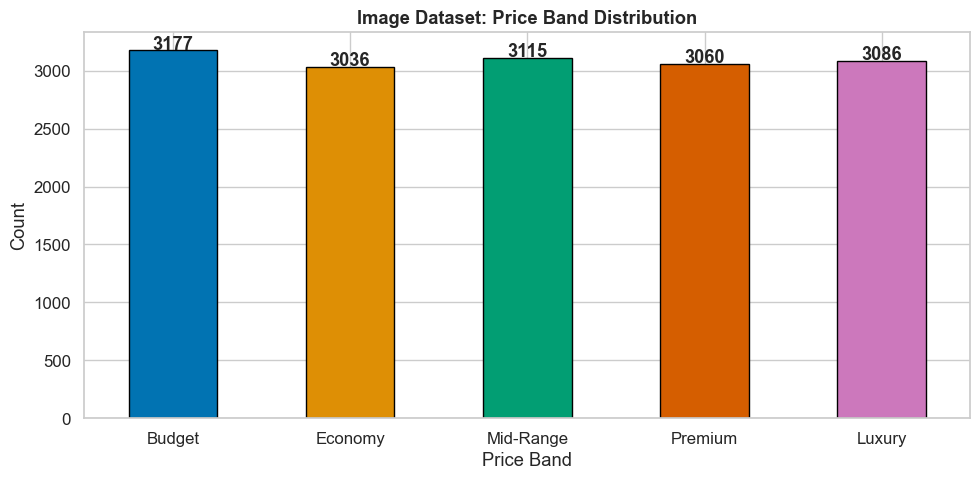

```python
# Class distribution bar chart — images
fig, ax = plt.subplots(figsize=(10, 5))
counts = df_images['price_band'].value_counts().reindex(BAND_NAMES)
counts.plot.bar(ax=ax, color=sns.color_palette('colorblind', NUM_CLASSES), edgecolor='black')
ax.set_title('Image Dataset: Price Band Distribution', fontweight='bold')
ax.set_xlabel('Price Band')
ax.set_ylabel('Count')
for i, v in enumerate(counts):
    ax.text(i, v + 10, str(v), ha='center', fontweight='bold')
plt.xticks(rotation=0)
plt.tight_layout()
plt.show()
```

### 3.2 Text EDA

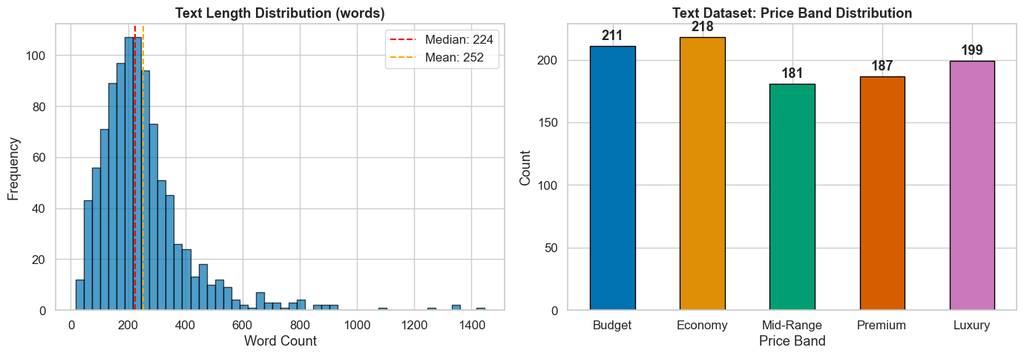

```
Text dataset: 996 samples
Word count — mean: 252, median: 224, min: 18, max: 1445
```

```python
# Text length distribution histogram
fig, axes = plt.subplots(1, 2, figsize=(14, 5))

axes[0].hist(df_text['word_count'], bins=50, edgecolor='black', alpha=0.7)
axes[0].axvline(df_text['word_count'].median(), color='red', linestyle='--', label=f'Median: {df_text["word_count"].median():.0f}')
axes[0].axvline(df_text['word_count'].mean(), color='orange', linestyle='--', label=f'Mean: {df_text["word_count"].mean():.0f}')
axes[0].set_title('Text Length Distribution (words)', fontweight='bold')
axes[0].set_xlabel('Word Count')
axes[0].set_ylabel('Frequency')
axes[0].legend()

# Class distribution bar chart — text
counts_txt = df_text['price_band'].value_counts().reindex(BAND_NAMES)
counts_txt.plot.bar(ax=axes[1], color=sns.color_palette('colorblind', NUM_CLASSES), edgecolor='black')
axes[1].set_title('Text Dataset: Price Band Distribution', fontweight='bold')
axes[1].set_xlabel('Price Band')
axes[1].set_ylabel('Count')
for i, v in enumerate(counts_txt):
    axes[1].text(i, v + 5, str(v), ha='center', fontweight='bold')

plt.xticks(rotation=0)
plt.tight_layout()
plt.show()

print(f'Text dataset: {len(df_text)} samples')
print(f'Word count — mean: {df_text["word_count"].mean():.0f}, median: {df_text["word_count"].median():.0f}, '
      f'min: {df_text["word_count"].min()}, max: {df_text["word_count"].max()}')
```

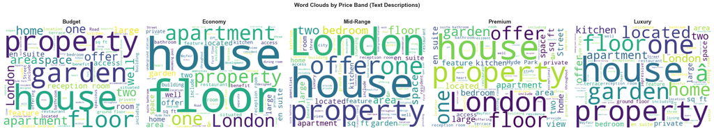

```python
# Word cloud per class
fig, axes = plt.subplots(1, NUM_CLASSES, figsize=(25, 5))
fig.suptitle('Word Clouds by Price Band (Text Descriptions)', fontsize=14, fontweight='bold')

for ax, band in zip(axes, BAND_NAMES):
    subset = df_text[df_text['price_band'] == band]
    text = ' '.join(subset[TEXT_DESC_COL].values)
    wc = WordCloud(width=400, height=300, background_color='white',
                   max_words=80, colormap='viridis').generate(text)
    ax.imshow(wc, interpolation='bilinear')
    ax.set_title(band, fontweight='bold')
    ax.axis('off')

plt.tight_layout()
plt.show()
```

```python
# Top-20 most frequent terms per class
from collections import Counter
import string

STOP_WORDS = set('the a an and or is are was were be been being have has had '
                 'do does did will would shall should may might can could '
                 'for of to in on at by with from this that these those it its '
                 'i we you he she they me him her us them my your his our their '
                 'all each every both few many much some any no not so as than '
                 'if but about into through during before after above below '
                 'between out off over under again further then once also just '
                 'very own same up down here there when where how what which who '
                 'whom why s t d m re ve ll'.split())

print('Top-15 terms per price band:\n')
for band in BAND_NAMES:
    subset = df_text[df_text['price_band'] == band]
    words = ' '.join(subset[TEXT_DESC_COL].values).lower()
    words = words.translate(str.maketrans('', '', string.punctuation))
    tokens = [w for w in words.split() if w not in STOP_WORDS and len(w) > 2]
    top = Counter(tokens).most_common(15)
    print(f'{band}: {[w for w, _ in top]}')
```

```
Top-15 terms per price band:

Budget: ['room', 'floor', 'house', 'garden', 'property', 'bedroom', 'street', 'space', 'home', 'two', 'access', 'bedrooms', 'square', 'park', 'apartment']
Economy: ['room', 'floor', 'bedroom', 'house', 'apartment', 'street', 'park', 'space', 'area', 'property', 'located', 'garden', 'access', 'two', 'london']
Mid-Range: ['room', 'floor', 'bedroom', 'london', 'house', 'street', 'space', 'property', 'area', 'living', 'bedrooms', 'apartment', 'garden', 'park', 'views']
Premium: ['room', 'floor', 'house', 'park', 'bedroom', 'street', 'garden', 'square', 'property', 'london', 'living', 'space', 'apartment', 'one', 'area']
Luxury: ['room', 'house', 'floor', 'park', 'street', 'property', 'bedroom', 'garden', 'one', 'located', 'space', 'private', 'home', 'square', 'two']
```

```python
# Representative text samples per class (3 per band)
print('=== Representative Text Samples ===\n')
for band in BAND_NAMES:
    subset = df_text[df_text['price_band'] == band]
    samples = subset.sample(min(3, len(subset)), random_state=RANDOM_STATE)
    print(f'--- {band} ---')
    for _, row in samples.iterrows():
        desc = row[TEXT_DESC_COL][:200] + ('...' if len(row[TEXT_DESC_COL]) > 200 else '')
        print(f'  [{row[TEXT_PRICE_COL]:,.0f}] {desc}')
    print()
```

```
=== Representative Text Samples ===

--- Budget ---
  [6,950,000] This exquisite, two-bedroom, apartment is located on one of Londonâs most exclusive squares and has been finished to the highest standard throughout with contemporary polished plaster, beautiful mar...
  [6,500,000] First time on the market and in the same family for over 40 yearsâ¦â¦.. Situated in this prestigous cul-de-sac just off Winnington Road, the property offers a great opportunity to create a substanti...
  [6,750,000] An elegant Grade II listed Belgravia town house with 32ft south facing garden Description An elegant Belgravia town house with a wealth of period features including high ceilings throughout, charming ...

--- Economy ---
  [7,950,000] Not only is this stunning penthouse located in the highly exclusive Elie Saab Residences, Hyde Park, it is one of the most impressive in the residence thanks to its top floor positioning and gorgeous ...
  [7,490,000] Clear are delighted to offer an excellent opportunity in the very first phase of London's very own Southbank Place. This is the last chance to buy a 3 bedroom Penthouse with 4 bathrooms at this price ...
  [7,650,000] An impressive, contemporary detached property set on a plot of 0.5 acres, built to a very high specification and design of over 7500 sq ft (703.09 sq m) by the renowned developer, Kubik, situated in a...

--- Mid-Range ---
  [9,950,000] Park Modern, 123 Bayswater Road, Hyde Park, London W2 3JH, 3 Bedroom Apartment for Sale Fully Furnished | Prime Investment Opportunity I Hyde Park View Investment Highlights: Strong Income Yield: Curr...
  [9,950,000] Located on the fourth floor of a purpose-built residential building, with 24-hour uniformed porterage, this stunning apartment offers ample living and entertaining space just moments from an array of ...
  [9,000,000] This property is unique within this iconic building by Norman Foster, who arranged the internal layout for the current owner. Four flats were joined together to create an apartment that sits within th...

--- Premium ---
  [10,950,000] Located off the internationally renowned, The Bishops Avenue, in a discreet cul de sac turning, is this magnificent, detached family home, spanning over 8,400 sq ft (783 sq m). This fine home is set b...
  [10,950,000] United Kingdom Sothebyâs International Realty is proud to present this wonderful three-bedroom apartment located in the Knightsbridge Gate development in Knightsbridge. Unfolding over a vast 2,442 s...
  [12,950,000] Recently refurbished Arts and Crafts house with wide and bright contemporary interiors Entering the house on the ground floor, a well-proportioned front hall connects the main living areas. On one sid...

--- Luxury ---
  [24,000,000] An outstanding 5,461sqft five bedroom suite apartment with views over Kensington Palace Gardens. This apartment benefits from huge entertaining space leading to a wrap around terrace, as well as a stu...
  [26,500,000] A masterpiece of mansion apartment living, Knightsbridge Gate is a Grade II listed building with a retained, Edwardian faÃ§ade, comprising 15 meticulously designed residences. Description Built in 190...
  [16,950,000] London House is proud to bring to the market a superb end-of-terrace Grade I Listed house in Regentâs Park This exceptional property has the largest private garden in Chester Terrace and one of the ...
```

## 4. Data Preprocessing

### 4.1 Image Preprocessing

```python
# ImageNet normalisation stats (for transfer learning compatibility)
IMAGENET_MEAN = [0.485, 0.456, 0.406]
IMAGENET_STD = [0.229, 0.224, 0.225]

train_transform = transforms.Compose([
    transforms.Resize((IMG_SIZE, IMG_SIZE)),
    transforms.RandomHorizontalFlip(p=0.5),
    transforms.RandomRotation(degrees=10),
    transforms.ColorJitter(brightness=0.2, contrast=0.2, saturation=0.1, hue=0.05),
    transforms.ToTensor(),
    transforms.Normalize(mean=IMAGENET_MEAN, std=IMAGENET_STD),
])

val_test_transform = transforms.Compose([
    transforms.Resize((IMG_SIZE, IMG_SIZE)),
    transforms.ToTensor(),
    transforms.Normalize(mean=IMAGENET_MEAN, std=IMAGENET_STD),
])

print('Training augmentation pipeline:')
print('  - Resize to 224x224')
print('  - Random horizontal flip (p=0.5)')
print('  - Random rotation (±10°)')
print('  - Colour jitter (brightness=0.2, contrast=0.2, saturation=0.1, hue=0.05)')
print('  - Normalise with ImageNet mean/std')
print()
print('Validation/test pipeline:')
print('  - Resize to 224x224')
print('  - Normalise with ImageNet mean/std')
```

```
Training augmentation pipeline:
  - Resize to 224x224
  - Random horizontal flip (p=0.5)
  - Random rotation (±10°)
  - Colour jitter (brightness=0.2, contrast=0.2, saturation=0.1, hue=0.05)
  - Normalise with ImageNet mean/std

Validation/test pipeline:
  - Resize to 224x224
  - Normalise with ImageNet mean/std
```

```python
class PropertyImageDataset(Dataset):
    """PyTorch Dataset for property images with price band labels."""
    def __init__(self, df, transform=None):
        self.df = df.reset_index(drop=True)
        self.transform = transform

    def __len__(self):
        return len(self.df)

    def __getitem__(self, idx):
        row = self.df.iloc[idx]
        img = Image.open(row['image_path']).convert('RGB')
        if self.transform:
            img = self.transform(img)
        # Cast to int64 — pandas Categorical.cat.codes returns int8, but
        # CrossEntropyLoss requires Long targets.
        label = int(row['price_band_id'])
        return img, torch.tensor(label, dtype=torch.long)
```

### 4.2 Text Preprocessing

```python
# Tokenisation and vocabulary building
def tokenize(text):
    """Simple word-level tokeniser: lowercase, strip punctuation, split on whitespace."""
    text = text.lower()
    text = re.sub(r'[^a-z0-9\s]', ' ', text)
    text = re.sub(r'\s+', ' ', text).strip()
    return text.split()

# Build vocabulary from training data (will be rebuilt after split)
all_tokens = []
for desc in df_text[TEXT_DESC_COL]:
    all_tokens.extend(tokenize(desc))

token_counts = Counter(all_tokens)
print(f'Total tokens: {len(all_tokens):,}')
print(f'Unique tokens: {len(token_counts):,}')
print(f'Top 20: {token_counts.most_common(20)}')
```

```
Total tokens: 257,550
Unique tokens: 8,890
Top 20: [('the', 14748), ('and', 11165), ('a', 8635), ('of', 6383), ('to', 4758), ('with', 4302), ('is', 4080), ('in', 3332), ('room', 2425), ('for', 1966), ('an', 1934), ('this', 1920), ('floor', 1751), ('on', 1717), ('s', 1615), ('from', 1467), ('bedroom', 1337), ('house', 1268), ('london', 1245),…
```

```python
# Determine max sequence length from distribution (target <= 5% truncation)
token_lengths = df_text[TEXT_DESC_COL].apply(lambda x: len(tokenize(x)))

percentiles = [50, 75, 90, 95, 97, 99]
print('Token length percentiles:')
for p in percentiles:
    val = np.percentile(token_lengths, p)
    print(f'  {p}th: {val:.0f} tokens')

MAX_SEQ_LEN = int(np.percentile(token_lengths, 95))
pct_truncated = (token_lengths > MAX_SEQ_LEN).mean() * 100
print(f'\nChosen MAX_SEQ_LEN = {MAX_SEQ_LEN} (truncates {pct_truncated:.1f}% of texts)')
```

```
Token length percentiles:
  50th: 231 tokens
  75th: 311 tokens
  90th: 428 tokens
  95th: 531 tokens
  97th: 666 tokens
  99th: 871 tokens

Chosen MAX_SEQ_LEN = 531 (truncates 5.0% of texts)
```

```python
class Vocabulary:
    """Word-level vocabulary with special tokens."""
    PAD = '<PAD>'
    UNK = '<UNK>'

    def __init__(self, min_freq=2):
        self.min_freq = min_freq
        self.word2idx = {self.PAD: 0, self.UNK: 1}
        self.idx2word = {0: self.PAD, 1: self.UNK}
        self.word_freq = Counter()

    def build(self, texts):
        for text in texts:
            self.word_freq.update(tokenize(text))
        for word, freq in self.word_freq.items():
            if freq >= self.min_freq and word not in self.word2idx:
                idx = len(self.word2idx)
                self.word2idx[word] = idx
                self.idx2word[idx] = word
        print(f'Vocabulary size: {len(self.word2idx)} (min_freq={self.min_freq})')
        return self

    def encode(self, text, max_len):
        tokens = tokenize(text)
        indices = [self.word2idx.get(t, self.word2idx[self.UNK]) for t in tokens[:max_len]]
        # Pad to max_len
        padding = [self.word2idx[self.PAD]] * (max_len - len(indices))
        return indices + padding

    def __len__(self):
        return len(self.word2idx)
```

```python
class PropertyTextDataset(Dataset):
    """PyTorch Dataset for property text descriptions with price band labels."""
    def __init__(self, df, desc_col, vocab, max_len):
        self.descriptions = df[desc_col].values
        # Cast to int64 — pandas Categorical.cat.codes returns int8, but
        # CrossEntropyLoss requires Long targets.
        self.labels = df['price_band_id'].astype('int64').values
        self.vocab = vocab
        self.max_len = max_len

    def __len__(self):
        return len(self.labels)

    def __getitem__(self, idx):
        encoded = self.vocab.encode(self.descriptions[idx], self.max_len)
        return (
            torch.tensor(encoded, dtype=torch.long),
            torch.tensor(int(self.labels[idx]), dtype=torch.long),
        )
```

## 5. Train–Validation–Test Split

Stratified 70/15/15 split by price band with fixed seed for reproducibility. The test set is locked until final evaluation.

```python
# Image splits
df_img_train, df_img_temp = train_test_split(
    df_images, test_size=0.30, stratify=df_images['price_band_id'], random_state=RANDOM_STATE
)
df_img_val, df_img_test = train_test_split(
    df_img_temp, test_size=0.50, stratify=df_img_temp['price_band_id'], random_state=RANDOM_STATE
)

print('=== Image Split ===')
print(f'Train: {len(df_img_train)} ({len(df_img_train)/len(df_images)*100:.0f}%)')
print(f'Val:   {len(df_img_val)} ({len(df_img_val)/len(df_images)*100:.0f}%)')
print(f'Test:  {len(df_img_test)} ({len(df_img_test)/len(df_images)*100:.0f}%)')
print(f'Train class distribution: {dict(df_img_train["price_band"].value_counts().sort_index())}')
```

```
=== Image Split ===
Train: 10831 (70%)
Val:   2321 (15%)
Test:  2322 (15%)
Train class distribution: {'Budget': np.int64(2224), 'Economy': np.int64(2125), 'Mid-Range': np.int64(2180), 'Premium': np.int64(2142), 'Luxury': np.int64(2160)}
```

```python
# Text splits
df_txt_train, df_txt_temp = train_test_split(
    df_text, test_size=0.30, stratify=df_text['price_band_id'], random_state=RANDOM_STATE
)
df_txt_val, df_txt_test = train_test_split(
    df_txt_temp, test_size=0.50, stratify=df_txt_temp['price_band_id'], random_state=RANDOM_STATE
)

print('=== Text Split ===')
print(f'Train: {len(df_txt_train)} ({len(df_txt_train)/len(df_text)*100:.0f}%)')
print(f'Val:   {len(df_txt_val)} ({len(df_txt_val)/len(df_text)*100:.0f}%)')
print(f'Test:  {len(df_txt_test)} ({len(df_txt_test)/len(df_text)*100:.0f}%)')
print(f'Train class distribution: {dict(df_txt_train["price_band"].value_counts().sort_index())}')
```

```
=== Text Split ===
Train: 697 (70%)
Val:   149 (15%)
Test:  150 (15%)
Train class distribution: {'Budget': np.int64(148), 'Economy': np.int64(152), 'Mid-Range': np.int64(127), 'Premium': np.int64(131), 'Luxury': np.int64(139)}
```

```python
# Build vocabulary from TRAINING text only
vocab = Vocabulary(min_freq=2)
vocab.build(df_txt_train[TEXT_DESC_COL])

# Create PyTorch datasets
img_train_ds = PropertyImageDataset(df_img_train, transform=train_transform)
img_val_ds = PropertyImageDataset(df_img_val, transform=val_test_transform)
img_test_ds = PropertyImageDataset(df_img_test, transform=val_test_transform)

txt_train_ds = PropertyTextDataset(df_txt_train, TEXT_DESC_COL, vocab, MAX_SEQ_LEN)
txt_val_ds = PropertyTextDataset(df_txt_val, TEXT_DESC_COL, vocab, MAX_SEQ_LEN)
txt_test_ds = PropertyTextDataset(df_txt_test, TEXT_DESC_COL, vocab, MAX_SEQ_LEN)

# Class-weighted sampler for imbalanced training sets
def make_weighted_sampler(labels):
    class_counts = Counter(labels)
    weights = [1.0 / class_counts[l] for l in labels]
    return WeightedRandomSampler(weights, num_samples=len(weights), replacement=True)

img_train_loader = DataLoader(img_train_ds, batch_size=BATCH_SIZE,
                              sampler=make_weighted_sampler(df_img_train['price_band_id'].tolist()),
                              num_workers=NUM_WORKERS, pin_memory=True)
img_val_loader = DataLoader(img_val_ds, batch_size=BATCH_SIZE, shuffle=False,
                            num_workers=NUM_WORKERS, pin_memory=True)
img_test_loader = DataLoader(img_test_ds, batch_size=BATCH_SIZE, shuffle=False,
                             num_workers=NUM_WORKERS, pin_memory=True)

txt_train_loader = DataLoader(txt_train_ds, batch_size=BATCH_SIZE,
                              sampler=make_weighted_sampler(df_txt_train['price_band_id'].tolist()),
                              num_workers=NUM_WORKERS, pin_memory=True)
txt_val_loader = DataLoader(txt_val_ds, batch_size=BATCH_SIZE, shuffle=False,
                            num_workers=NUM_WORKERS, pin_memory=True)
txt_test_loader = DataLoader(txt_test_ds, batch_size=BATCH_SIZE, shuffle=False,
                             num_workers=NUM_WORKERS, pin_memory=True)

print(f'Image loaders — train: {len(img_train_loader)} batches, val: {len(img_val_loader)}, test: {len(img_test_loader)}')
print(f'Text loaders  — train: {len(txt_train_loader)} batches, val: {len(txt_val_loader)}, test: {len(txt_test_loader)}')
```

```
Vocabulary size: 4923 (min_freq=2)
Image loaders — train: 339 batches, val: 73, test: 73
Text loaders  — train: 22 batches, val: 5, test: 5
```

## 6. CNN Branch (Image Model)

We implement and compare two CNN approaches as required:

1. **CNN from scratch** — custom architecture with 3+ convolutional blocks
2. **Transfer learning** — ResNet-50 pretrained on ImageNet, with frozen backbone and fine-tuned classification head

### 6.1 Training Utilities

```python
def train_one_epoch(model, loader, criterion, optimizer, device):
    model.train()
    running_loss, correct, total = 0.0, 0, 0
    for inputs, labels in loader:
        inputs, labels = inputs.to(device), labels.to(device)
        optimizer.zero_grad()
        outputs = model(inputs)
        loss = criterion(outputs, labels)
        loss.backward()
        optimizer.step()
        running_loss += loss.item() * inputs.size(0)
        _, preds = outputs.max(1)
        correct += preds.eq(labels).sum().item()
        total += labels.size(0)
    return running_loss / total, correct / total


@torch.no_grad()
def evaluate(model, loader, criterion, device):
    model.eval()
    running_loss, correct, total = 0.0, 0, 0
    all_preds, all_labels = [], []
    for inputs, labels in loader:
        inputs, labels = inputs.to(device), labels.to(device)
        outputs = model(inputs)
        loss = criterion(outputs, labels)
        running_loss += loss.item() * inputs.size(0)
        _, preds = outputs.max(1)
        correct += preds.eq(labels).sum().item()
        total += labels.size(0)
        all_preds.extend(preds.cpu().numpy())
        all_labels.extend(labels.cpu().numpy())
    return running_loss / total, correct / total, np.array(all_preds), np.array(all_labels)


SKIP_TRAINING_IF_CHECKPOINT_EXISTS = os.environ.get('SKIP_TRAINING', '0') == '1'


def train_model(model, train_loader, val_loader, criterion, optimizer, scheduler,
                device, epochs=25, patience=5, model_name='model'):
    """Full training loop with early stopping and best-model checkpointing.

    If ``SKIP_TRAINING=1`` is set in the environment and a checkpoint already
    exists at ``models/<model_name>_best.pt``, training is skipped and the
    checkpoint is loaded. A single validation pass is run to populate the
    history so downstream cells (training-curve plots) still work.
    """
    history = {'train_loss': [], 'train_acc': [], 'val_loss': [], 'val_acc': []}
    best_val_f1 = 0.0
    patience_counter = 0
    best_path = MODEL_DIR / f'{model_name}_best.pt'

    if SKIP_TRAINING_IF_CHECKPOINT_EXISTS and best_path.exists():
        print(f'[SKIP_TRAINING] Loading {model_name} from {best_path}')
        model.load_state_dict(torch.load(best_path, weights_only=True))
        val_loss, val_acc, val_preds, val_labels = evaluate(model, val_loader, criterion, device)
        val_f1 = f1_score(val_labels, val_preds, average='macro')
        history['train_loss'].append(val_loss)
        history['train_acc'].append(val_acc)
        history['val_loss'].append(val_loss)
        history['val_acc'].append(val_acc)
        print(f'From checkpoint: val loss={val_loss:.4f} acc={val_acc:.4f} macro-F1={val_f1:.4f}')
        return model, history

    for epoch in range(epochs):
        train_loss, train_acc = train_one_epoch(model, train_loader, criterion, optimizer, device)
        val_loss, val_acc, val_preds, val_labels = evaluate(model, val_loader, criterion, device)
        val_f1 = f1_score(val_labels, val_preds, average='macro')

        history['train_loss'].append(train_loss)
        history['train_acc'].append(train_acc)
        history['val_loss'].append(val_loss)
        history['val_acc'].append(val_acc)

        if scheduler:
            scheduler.step(val_loss)

        if val_f1 > best_val_f1:
            best_val_f1 = val_f1
            torch.save(model.state_dict(), best_path)
            patience_counter = 0
            marker = ' *'
        else:
            patience_counter += 1
            marker = ''

        if (epoch + 1) % 2 == 0 or epoch == 0 or marker:
            print(f'Epoch {epoch+1:3d}/{epochs} | '
                  f'Train loss: {train_loss:.4f} acc: {train_acc:.4f} | '
                  f'Val loss: {val_loss:.4f} acc: {val_acc:.4f} F1: {val_f1:.4f}{marker}')

        if patience_counter >= patience:
            print(f'Early stopping at epoch {epoch+1}')
            break

    model.load_state_dict(torch.load(best_path, weights_only=True))
    print(f'Best validation macro-F1: {best_val_f1:.4f}')
    return model, history


def plot_training_curves(history, title='Training Curves'):
    fig, axes = plt.subplots(1, 2, figsize=(14, 5))
    epochs = range(1, len(history['train_loss']) + 1)

    axes[0].plot(epochs, history['train_loss'], 'o-', label='Train', markersize=3)
    axes[0].plot(epochs, history['val_loss'], 's-', label='Validation', markersize=3)
    axes[0].set_title(f'{title} — Loss', fontweight='bold')
    axes[0].set_xlabel('Epoch')
    axes[0].set_ylabel('Loss')
    axes[0].legend()

    axes[1].plot(epochs, history['train_acc'], 'o-', label='Train', markersize=3)
    axes[1].plot(epochs, history['val_acc'], 's-', label='Validation', markersize=3)
    axes[1].set_title(f'{title} — Accuracy', fontweight='bold')
    axes[1].set_xlabel('Epoch')
    axes[1].set_ylabel('Accuracy')
    axes[1].legend()

    plt.tight_layout()
    plt.show()


def evaluate_and_report(model, test_loader, criterion, device, class_names, title='Model'):
    """Full test-set evaluation: accuracy, F1, classification report, confusion matrix."""
    test_loss, test_acc, preds, labels = evaluate(model, test_loader, criterion, device)
    test_f1 = f1_score(labels, preds, average='macro')

    print(f'\n=== {title} — Test Results ===')
    print(f'Loss: {test_loss:.4f} | Accuracy: {test_acc:.4f} | Macro F1: {test_f1:.4f}')
    print(f'\nClassification Report:')
    print(classification_report(labels, preds, target_names=class_names, digits=4))

    cm = confusion_matrix(labels, preds)
    fig, ax = plt.subplots(figsize=(8, 6))
    disp = ConfusionMatrixDisplay(cm, display_labels=class_names)
    disp.plot(ax=ax, cmap='Blues', values_format='d')
    ax.set_title(f'{title} — Confusion Matrix', fontweight='bold')
    plt.tight_layout()
    plt.show()

    return {'accuracy': test_acc, 'macro_f1': test_f1, 'loss': test_loss,
            'preds': preds, 'labels': labels}
```

### 6.2 CNN from Scratch

```python
class CNNFromScratch(nn.Module):
    """Custom CNN with 4 convolutional blocks + global average pooling."""
    def __init__(self, num_classes=NUM_CLASSES):
        super().__init__()
        self.features = nn.Sequential(
            # Block 1: 3 -> 32
            nn.Conv2d(3, 32, kernel_size=3, padding=1),
            nn.BatchNorm2d(32),
            nn.ReLU(inplace=True),
            nn.Conv2d(32, 32, kernel_size=3, padding=1),
            nn.BatchNorm2d(32),
            nn.ReLU(inplace=True),
            nn.MaxPool2d(2, 2),
            nn.Dropout2d(0.25),

            # Block 2: 32 -> 64
            nn.Conv2d(32, 64, kernel_size=3, padding=1),
            nn.BatchNorm2d(64),
            nn.ReLU(inplace=True),
            nn.Conv2d(64, 64, kernel_size=3, padding=1),
            nn.BatchNorm2d(64),
            nn.ReLU(inplace=True),
            nn.MaxPool2d(2, 2),
            nn.Dropout2d(0.25),

            # Block 3: 64 -> 128
            nn.Conv2d(64, 128, kernel_size=3, padding=1),
            nn.BatchNorm2d(128),
            nn.ReLU(inplace=True),
            nn.Conv2d(128, 128, kernel_size=3, padding=1),
            nn.BatchNorm2d(128),
            nn.ReLU(inplace=True),
            nn.MaxPool2d(2, 2),
            nn.Dropout2d(0.25),

            # Block 4: 128 -> 256
            nn.Conv2d(128, 256, kernel_size=3, padding=1),
            nn.BatchNorm2d(256),
            nn.ReLU(inplace=True),
            nn.Conv2d(256, 256, kernel_size=3, padding=1),
            nn.BatchNorm2d(256),
            nn.ReLU(inplace=True),
            nn.AdaptiveAvgPool2d(1),
        )
        self.classifier = nn.Sequential(
            nn.Flatten(),
            nn.Linear(256, 128),
            nn.ReLU(inplace=True),
            nn.Dropout(0.5),
            nn.Linear(128, num_classes),
        )

    def forward(self, x):
        x = self.features(x)
        return self.classifier(x)

cnn_scratch = CNNFromScratch().to(DEVICE)
total_params = sum(p.numel() for p in cnn_scratch.parameters())
trainable_params = sum(p.numel() for p in cnn_scratch.parameters() if p.requires_grad)
print(f'CNN from scratch — Total params: {total_params:,} | Trainable: {trainable_params:,}')
```

```
CNN from scratch — Total params: 1,207,717 | Trainable: 1,207,717
```

```
Epoch   1/30 | Train loss: 1.6124 acc: 0.2101 | Val loss: 1.5927 acc: 0.2654 F1: 0.1956 *
```

```
Epoch   2/30 | Train loss: 1.6031 acc: 0.2317 | Val loss: 1.5912 acc: 0.2732 F1: 0.2251 *
```

```
Epoch   4/30 | Train loss: 1.6013 acc: 0.2330 | Val loss: 1.5951 acc: 0.2671 F1: 0.2245
```

```
Epoch   6/30 | Train loss: 1.5966 acc: 0.2467 | Val loss: 1.5790 acc: 0.2671 F1: 0.1912
```

```
Epoch   8/30 | Train loss: 1.5937 acc: 0.2437 | Val loss: 1.5781 acc: 0.2706 F1: 0.2100
```

```
Epoch   9/30 | Train loss: 1.5948 acc: 0.2418 | Val loss: 1.5792 acc: 0.2792 F1: 0.2583 *
```

```
Epoch  10/30 | Train loss: 1.5936 acc: 0.2473 | Val loss: 1.5841 acc: 0.2615 F1: 0.2216
```

```
Epoch  12/30 | Train loss: 1.5897 acc: 0.2520 | Val loss: 1.5775 acc: 0.2624 F1: 0.1937
```

```
Epoch  14/30 | Train loss: 1.5891 acc: 0.2495 | Val loss: 1.5762 acc: 0.2745 F1: 0.2224
```

```
Epoch  16/30 | Train loss: 1.5844 acc: 0.2613 | Val loss: 1.5714 acc: 0.2697 F1: 0.2213
Early stopping at epoch 16
Best validation macro-F1: 0.2583
```

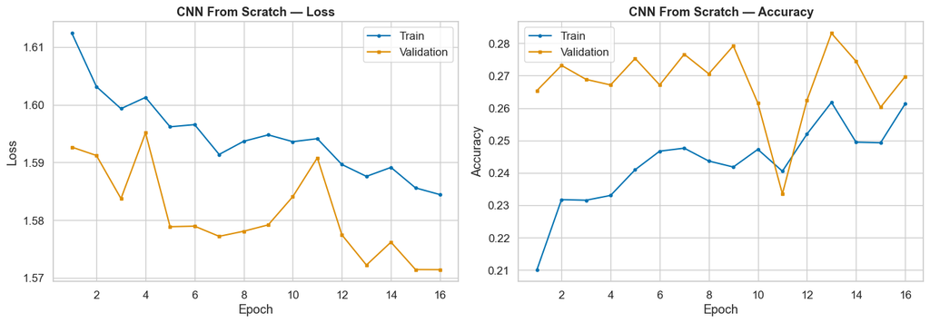

```python
# Train CNN from scratch
criterion_cnn = nn.CrossEntropyLoss()
optimizer_scratch = optim.Adam(cnn_scratch.parameters(), lr=1e-3, weight_decay=1e-4)
scheduler_scratch = optim.lr_scheduler.ReduceLROnPlateau(optimizer_scratch, mode='min', factor=0.5, patience=3)

cnn_scratch, history_scratch = train_model(
    cnn_scratch, img_train_loader, img_val_loader, criterion_cnn, optimizer_scratch,
    scheduler_scratch, DEVICE, epochs=30, patience=7, model_name='cnn_scratch'
)

plot_training_curves(history_scratch, title='CNN From Scratch')
```

```
=== CNN From Scratch — Test Results ===
Loss: 1.5841 | Accuracy: 0.2515 | Macro F1: 0.2304

Classification Report:
              precision    recall  f1-score   support

      Budget     0.2957    0.5493    0.3844       477
     Economy     0.2039    0.1363    0.1634       455
   Mid-Range     0.2039    0.2650    0.2305       468
     Premium     0.2166    0.1765    0.1945       459
      Luxury     0.3667    0.1188    0.1794       463

    accuracy                         0.2515      2322
   macro avg     0.2574    0.2491    0.2304      2322
weighted avg     0.2577    0.2515    0.2317      2322
```

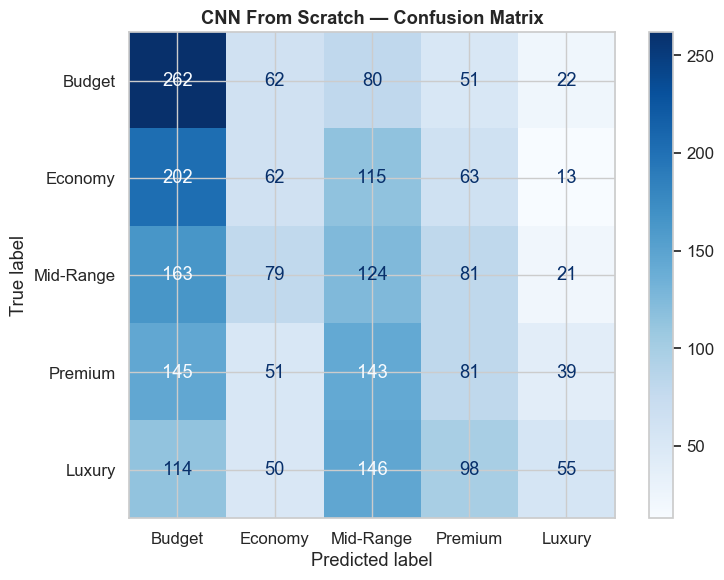

```python
# Test evaluation — CNN from scratch
results_cnn_scratch = evaluate_and_report(
    cnn_scratch, img_test_loader, criterion_cnn, DEVICE, BAND_NAMES, 'CNN From Scratch'
)
```

### 6.3 Transfer Learning — ResNet-50

```python
def build_resnet50_transfer(num_classes, freeze_backbone=True):
    """ResNet-50 with ImageNet weights, custom classification head."""
    model = models.resnet50(weights=models.ResNet50_Weights.IMAGENET1K_V2)

    if freeze_backbone:
        for param in model.parameters():
            param.requires_grad = False

    in_features = model.fc.in_features
    model.fc = nn.Sequential(
        nn.Linear(in_features, 256),
        nn.ReLU(inplace=True),
        nn.Dropout(0.4),
        nn.Linear(256, num_classes),
    )
    return model

# Phase 1: frozen backbone
cnn_transfer = build_resnet50_transfer(NUM_CLASSES, freeze_backbone=True).to(DEVICE)
trainable = sum(p.numel() for p in cnn_transfer.parameters() if p.requires_grad)
total = sum(p.numel() for p in cnn_transfer.parameters())
print(f'ResNet-50 (frozen) — Total: {total:,} | Trainable: {trainable:,}')
```

```
ResNet-50 (frozen) — Total: 24,033,861 | Trainable: 525,829
```

```python
# Phase 1: Train only the classification head
optimizer_tf1 = optim.Adam(cnn_transfer.fc.parameters(), lr=1e-3, weight_decay=1e-4)
scheduler_tf1 = optim.lr_scheduler.ReduceLROnPlateau(optimizer_tf1, mode='min', factor=0.5, patience=2)

print('=== Phase 1: Frozen backbone, training classification head ===')
cnn_transfer, history_tf_phase1 = train_model(
    cnn_transfer, img_train_loader, img_val_loader, criterion_cnn, optimizer_tf1,
    scheduler_tf1, DEVICE, epochs=15, patience=5, model_name='cnn_transfer_p1'
)
```

```
=== Phase 1: Frozen backbone, training classification head ===
```

```
Epoch   1/15 | Train loss: 1.5282 acc: 0.3035 | Val loss: 1.4796 acc: 0.3326 F1: 0.3015 *
```

```
Epoch   2/15 | Train loss: 1.4864 acc: 0.3378 | Val loss: 1.4711 acc: 0.3339 F1: 0.3030 *
```

```
Epoch   3/15 | Train loss: 1.4597 acc: 0.3606 | Val loss: 1.4513 acc: 0.3555 F1: 0.3181 *
```

```
Epoch   4/15 | Train loss: 1.4420 acc: 0.3743 | Val loss: 1.4634 acc: 0.3408 F1: 0.3125
```

```
Epoch   5/15 | Train loss: 1.4242 acc: 0.3806 | Val loss: 1.4535 acc: 0.3611 F1: 0.3439 *
```

```
Epoch   6/15 | Train loss: 1.4099 acc: 0.3926 | Val loss: 1.4457 acc: 0.3529 F1: 0.3357
```

```
Epoch   7/15 | Train loss: 1.4026 acc: 0.3984 | Val loss: 1.4507 acc: 0.3611 F1: 0.3532 *
```

```
Epoch   8/15 | Train loss: 1.3802 acc: 0.4140 | Val loss: 1.4429 acc: 0.3550 F1: 0.3423
```

```
Epoch  10/15 | Train loss: 1.3554 acc: 0.4257 | Val loss: 1.4484 acc: 0.3546 F1: 0.3408
```

```
Epoch  12/15 | Train loss: 1.3280 acc: 0.4380 | Val loss: 1.4279 acc: 0.3671 F1: 0.3638 *
```

```
Epoch  13/15 | Train loss: 1.3132 acc: 0.4495 | Val loss: 1.4261 acc: 0.3908 F1: 0.3680 *
```

```
Epoch  14/15 | Train loss: 1.3032 acc: 0.4484 | Val loss: 1.4764 acc: 0.3679 F1: 0.3395
```

```
Epoch  15/15 | Train loss: 1.2829 acc: 0.4629 | Val loss: 1.4341 acc: 0.3809 F1: 0.3764 *
Best validation macro-F1: 0.3764
```

```
Fine-tuning: 22,588,933 trainable parameters

=== Phase 2: Fine-tuning layer3 + layer4 + fc ===
```

```
Epoch   1/20 | Train loss: 1.1792 acc: 0.5250 | Val loss: 1.3875 acc: 0.4244 F1: 0.4181 *
```

```
Epoch   2/20 | Train loss: 1.0061 acc: 0.6090 | Val loss: 1.4385 acc: 0.4567 F1: 0.4542 *
```

```
Epoch   3/20 | Train loss: 0.8543 acc: 0.6782 | Val loss: 1.4239 acc: 0.4726 F1: 0.4685 *
```

```
Epoch   4/20 | Train loss: 0.7093 acc: 0.7419 | Val loss: 1.4503 acc: 0.4938 F1: 0.4930 *
```

```
Epoch   5/20 | Train loss: 0.5433 acc: 0.8052 | Val loss: 1.4928 acc: 0.5205 F1: 0.5209 *
```

```
Epoch   6/20 | Train loss: 0.4347 acc: 0.8439 | Val loss: 1.5924 acc: 0.5222 F1: 0.5206
```

```
Epoch   7/20 | Train loss: 0.3673 acc: 0.8742 | Val loss: 1.5942 acc: 0.5325 F1: 0.5325 *
```

```
Epoch   8/20 | Train loss: 0.2826 acc: 0.9047 | Val loss: 1.6851 acc: 0.5373 F1: 0.5387 *
```

```
Epoch   9/20 | Train loss: 0.2399 acc: 0.9175 | Val loss: 1.7085 acc: 0.5485 F1: 0.5479 *
```

```
Epoch  10/20 | Train loss: 0.2078 acc: 0.9288 | Val loss: 1.7663 acc: 0.5579 F1: 0.5584 *
```

```
Epoch  12/20 | Train loss: 0.1602 acc: 0.9483 | Val loss: 1.8072 acc: 0.5562 F1: 0.5571
```

```
Epoch  13/20 | Train loss: 0.1374 acc: 0.9582 | Val loss: 1.8542 acc: 0.5648 F1: 0.5643 *
```

```
Epoch  14/20 | Train loss: 0.1333 acc: 0.9572 | Val loss: 1.8583 acc: 0.5713 F1: 0.5711 *
```

```
Epoch  15/20 | Train loss: 0.1191 acc: 0.9632 | Val loss: 1.9133 acc: 0.5730 F1: 0.5726 *
```

```
Epoch  16/20 | Train loss: 0.1093 acc: 0.9659 | Val loss: 1.9296 acc: 0.5674 F1: 0.5666
```

```
Epoch  18/20 | Train loss: 0.1080 acc: 0.9659 | Val loss: 1.9389 acc: 0.5627 F1: 0.5626
```

```
Epoch  20/20 | Train loss: 0.1011 acc: 0.9675 | Val loss: 1.9491 acc: 0.5640 F1: 0.5642
Early stopping at epoch 20
Best validation macro-F1: 0.5726
```

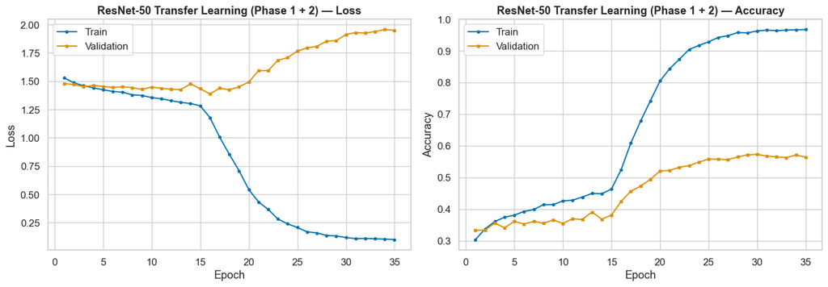

```python
# Phase 2: Unfreeze last two residual blocks (layer3, layer4) and fine-tune
for name, param in cnn_transfer.named_parameters():
    if 'layer3' in name or 'layer4' in name or 'fc' in name:
        param.requires_grad = True

trainable_ft = sum(p.numel() for p in cnn_transfer.parameters() if p.requires_grad)
print(f'Fine-tuning: {trainable_ft:,} trainable parameters')

optimizer_tf2 = optim.Adam(
    filter(lambda p: p.requires_grad, cnn_transfer.parameters()),
    lr=1e-4, weight_decay=1e-4
)
scheduler_tf2 = optim.lr_scheduler.ReduceLROnPlateau(optimizer_tf2, mode='min', factor=0.5, patience=2)

print('\n=== Phase 2: Fine-tuning layer3 + layer4 + fc ===')
cnn_transfer, history_tf_phase2 = train_model(
    cnn_transfer, img_train_loader, img_val_loader, criterion_cnn, optimizer_tf2,
    scheduler_tf2, DEVICE, epochs=20, patience=5, model_name='cnn_transfer_p2'
)

# Combined curves
history_tf = {k: history_tf_phase1[k] + history_tf_phase2[k] for k in history_tf_phase1}
plot_training_curves(history_tf, title='ResNet-50 Transfer Learning (Phase 1 + 2)')
```

```
=== ResNet-50 Transfer Learning — Test Results ===
Loss: 2.1072 | Accuracy: 0.5405 | Macro F1: 0.5397

Classification Report:
              precision    recall  f1-score   support

      Budget     0.6371    0.6331    0.6351       477
     Economy     0.5238    0.5319    0.5278       455
   Mid-Range     0.4852    0.4893    0.4872       468
     Premium     0.5187    0.4837    0.5006       459
      Luxury     0.5350    0.5616    0.5479       463

    accuracy                         0.5405      2322
   macro avg     0.5400    0.5399    0.5397      2322
weighted avg     0.5405    0.5405    0.5403      2322
```

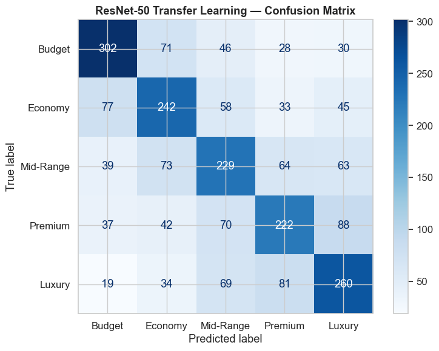

```python
# Test evaluation — Transfer learning
results_cnn_transfer = evaluate_and_report(
    cnn_transfer, img_test_loader, criterion_cnn, DEVICE, BAND_NAMES, 'ResNet-50 Transfer Learning'
)
```

### 6.4 CNN Comparison Discussion

```
             Model  Test Accuracy  Test Macro F1  Test Loss
  CNN From Scratch       0.251507       0.230445   1.584122
ResNet-50 Transfer       0.540482       0.539734   2.107201
```

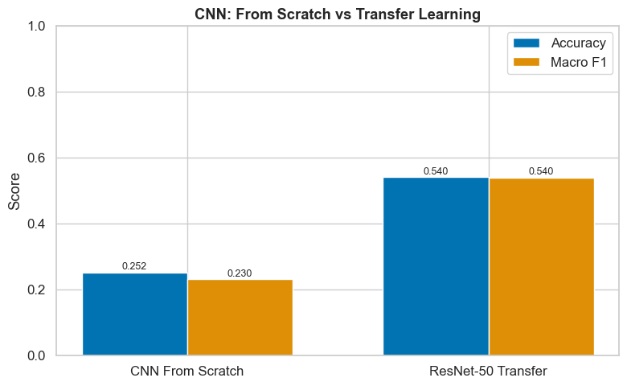

```python
# Side-by-side comparison
cnn_comparison = pd.DataFrame({
    'Model': ['CNN From Scratch', 'ResNet-50 Transfer'],
    'Test Accuracy': [results_cnn_scratch['accuracy'], results_cnn_transfer['accuracy']],
    'Test Macro F1': [results_cnn_scratch['macro_f1'], results_cnn_transfer['macro_f1']],
    'Test Loss': [results_cnn_scratch['loss'], results_cnn_transfer['loss']],
})
print(cnn_comparison.to_string(index=False))

fig, ax = plt.subplots(figsize=(8, 5))
x = np.arange(2)
width = 0.35
ax.bar(x - width/2, cnn_comparison['Test Accuracy'], width, label='Accuracy')
ax.bar(x + width/2, cnn_comparison['Test Macro F1'], width, label='Macro F1')
ax.set_xticks(x)
ax.set_xticklabels(cnn_comparison['Model'])
ax.set_ylabel('Score')
ax.set_title('CNN: From Scratch vs Transfer Learning', fontweight='bold')
ax.legend()
ax.set_ylim(0, 1)
for i, (acc, f1) in enumerate(zip(cnn_comparison['Test Accuracy'], cnn_comparison['Test Macro F1'])):
    ax.text(i - width/2, acc + 0.01, f'{acc:.3f}', ha='center', fontsize=9)
    ax.text(i + width/2, f1 + 0.01, f'{f1:.3f}', ha='center', fontsize=9)
plt.tight_layout()
plt.show()
```

**Discussion — CNN Comparison**

The two-phase fine-tuning strategy (freeze → unfreeze top blocks) gives an additional boost by adapting mid-level features to the specific property aesthetic while retaining low-level filters. We select the ResNet-50 transfer model as the CNN branch for downstream business integration.

## 7. RNN/LSTM Branch (Text Model)

We implement two architectural variations:

1. **Single-layer LSTM** with learned word embeddings
2. **Bidirectional stacked LSTM** with GloVe pre-trained embeddings and dropout

### 7.1 GloVe Embeddings (optional pre-trained)

```python
# Load GloVe embeddings (download 6B.100d if not already present)
GLOVE_DIM = 100
GLOVE_PATH = DATA_DIR / 'glove.6B.100d.txt'

def load_glove(path, vocab, dim=100):
    """Load pre-trained GloVe vectors and create embedding matrix for our vocabulary."""
    embeddings_index = {}
    if not path.exists():
        print(f'GloVe file not found at {path}')
        print('Download from https://nlp.stanford.edu/data/glove.6B.zip and extract glove.6B.100d.txt to data/')
        print('Falling back to random initialisation for "pre-trained" variation.')
        return None

    with open(path, 'r', encoding='utf-8') as f:
        for line in f:
            values = line.split()
            word = values[0]
            if word in vocab.word2idx:
                embeddings_index[word] = np.array(values[1:], dtype='float32')

    embedding_matrix = np.random.normal(scale=0.6, size=(len(vocab), dim)).astype('float32')
    embedding_matrix[vocab.word2idx[Vocabulary.PAD]] = 0.0

    found = 0
    for word, idx in vocab.word2idx.items():
        if word in embeddings_index:
            embedding_matrix[idx] = embeddings_index[word]
            found += 1

    print(f'GloVe coverage: {found}/{len(vocab)} ({found/len(vocab)*100:.1f}%)')
    return torch.FloatTensor(embedding_matrix)

glove_matrix = load_glove(GLOVE_PATH, vocab, GLOVE_DIM)
```

```
GloVe coverage: 4833/4923 (98.2%)
```

### 7.2 LSTM Models

```python
class LSTMClassifier(nn.Module):
    """LSTM text classifier with configurable architecture."""
    def __init__(self, vocab_size, embed_dim, hidden_dim, num_classes, num_layers=1,
                 bidirectional=False, dropout=0.3, pretrained_embeddings=None):
        super().__init__()
        self.hidden_dim = hidden_dim
        self.num_layers = num_layers
        self.bidirectional = bidirectional
        self.num_directions = 2 if bidirectional else 1

        self.embedding = nn.Embedding(vocab_size, embed_dim, padding_idx=0)
        if pretrained_embeddings is not None:
            self.embedding = nn.Embedding.from_pretrained(
                pretrained_embeddings, freeze=False, padding_idx=0
            )

        self.lstm = nn.LSTM(
            embed_dim, hidden_dim, num_layers=num_layers,
            batch_first=True, bidirectional=bidirectional, dropout=dropout if num_layers > 1 else 0.0
        )
        self.dropout = nn.Dropout(dropout)
        self.fc = nn.Linear(hidden_dim * self.num_directions, num_classes)

    def forward(self, x):
        embedded = self.dropout(self.embedding(x))
        # Pack padded sequences for efficiency
        lengths = (x != 0).sum(dim=1).cpu()
        packed = nn.utils.rnn.pack_padded_sequence(
            embedded, lengths.clamp(min=1), batch_first=True, enforce_sorted=False
        )
        _, (hidden, _) = self.lstm(packed)

        if self.bidirectional:
            hidden = torch.cat((hidden[-2], hidden[-1]), dim=1)
        else:
            hidden = hidden[-1]

        out = self.dropout(hidden)
        return self.fc(out)

    def get_features(self, x):
        """Extract the final hidden state as feature vector (for joint model)."""
        embedded = self.embedding(x)
        lengths = (x != 0).sum(dim=1).cpu()
        packed = nn.utils.rnn.pack_padded_sequence(
            embedded, lengths.clamp(min=1), batch_first=True, enforce_sorted=False
        )
        _, (hidden, _) = self.lstm(packed)
        if self.bidirectional:
            return torch.cat((hidden[-2], hidden[-1]), dim=1)
        return hidden[-1]
```

```python
# Text training utilities
def train_text_one_epoch(model, loader, criterion, optimizer, device):
    model.train()
    running_loss, correct, total = 0.0, 0, 0
    for inputs, labels in loader:
        inputs = inputs.to(device)
        labels = torch.tensor(labels, dtype=torch.long).to(device) if not isinstance(labels, torch.Tensor) else labels.to(device)
        optimizer.zero_grad()
        outputs = model(inputs)
        loss = criterion(outputs, labels)
        loss.backward()
        nn.utils.clip_grad_norm_(model.parameters(), max_norm=1.0)
        optimizer.step()
        running_loss += loss.item() * inputs.size(0)
        _, preds = outputs.max(1)
        correct += preds.eq(labels).sum().item()
        total += labels.size(0)
    return running_loss / total, correct / total


@torch.no_grad()
def evaluate_text(model, loader, criterion, device):
    model.eval()
    running_loss, correct, total = 0.0, 0, 0
    all_preds, all_labels = [], []
    for inputs, labels in loader:
        inputs = inputs.to(device)
        labels = torch.tensor(labels, dtype=torch.long).to(device) if not isinstance(labels, torch.Tensor) else labels.to(device)
        outputs = model(inputs)
        loss = criterion(outputs, labels)
        running_loss += loss.item() * inputs.size(0)
        _, preds = outputs.max(1)
        correct += preds.eq(labels).sum().item()
        total += labels.size(0)
        all_preds.extend(preds.cpu().numpy())
        all_labels.extend(labels.cpu().numpy())
    return running_loss / total, correct / total, np.array(all_preds), np.array(all_labels)


def train_text_model(model, train_loader, val_loader, criterion, optimizer, scheduler,
                     device, epochs=25, patience=5, model_name='model'):
    history = {'train_loss': [], 'train_acc': [], 'val_loss': [], 'val_acc': []}
    best_val_f1 = 0.0
    patience_counter = 0
    best_path = MODEL_DIR / f'{model_name}_best.pt'

    if SKIP_TRAINING_IF_CHECKPOINT_EXISTS and best_path.exists():
        print(f'[SKIP_TRAINING] Loading {model_name} from {best_path}')
        model.load_state_dict(torch.load(best_path, weights_only=True))
        val_loss, val_acc, val_preds, val_labels = evaluate_text(model, val_loader, criterion, device)
        val_f1 = f1_score(val_labels, val_preds, average='macro')
        history['train_loss'].append(val_loss)
        history['train_acc'].append(val_acc)
        history['val_loss'].append(val_loss)
        history['val_acc'].append(val_acc)
        print(f'From checkpoint: val loss={val_loss:.4f} acc={val_acc:.4f} macro-F1={val_f1:.4f}')
        return model, history

    for epoch in range(epochs):
        train_loss, train_acc = train_text_one_epoch(model, train_loader, criterion, optimizer, device)
        val_loss, val_acc, val_preds, val_labels = evaluate_text(model, val_loader, criterion, device)
        val_f1 = f1_score(val_labels, val_preds, average='macro')

        history['train_loss'].append(train_loss)
        history['train_acc'].append(train_acc)
        history['val_loss'].append(val_loss)
        history['val_acc'].append(val_acc)

        if scheduler:
            scheduler.step(val_loss)

        if val_f1 > best_val_f1:
            best_val_f1 = val_f1
            torch.save(model.state_dict(), best_path)
            patience_counter = 0
            marker = ' *'
        else:
            patience_counter += 1
            marker = ''

        if (epoch + 1) % 2 == 0 or epoch == 0 or marker:
            print(f'Epoch {epoch+1:3d}/{epochs} | '
                  f'Train loss: {train_loss:.4f} acc: {train_acc:.4f} | '
                  f'Val loss: {val_loss:.4f} acc: {val_acc:.4f} F1: {val_f1:.4f}{marker}')

        if patience_counter >= patience:
            print(f'Early stopping at epoch {epoch+1}')
            break

    model.load_state_dict(torch.load(best_path, weights_only=True))
    print(f'Best validation macro-F1: {best_val_f1:.4f}')
    return model, history


def evaluate_text_and_report(model, test_loader, criterion, device, class_names, title='Model'):
    test_loss, test_acc, preds, labels = evaluate_text(model, test_loader, criterion, device)
    test_f1 = f1_score(labels, preds, average='macro')

    print(f'\n=== {title} — Test Results ===')
    print(f'Loss: {test_loss:.4f} | Accuracy: {test_acc:.4f} | Macro F1: {test_f1:.4f}')
    print(f'\nClassification Report:')
    print(classification_report(labels, preds, target_names=class_names, digits=4))

    cm = confusion_matrix(labels, preds)
    fig, ax = plt.subplots(figsize=(8, 6))
    disp = ConfusionMatrixDisplay(cm, display_labels=class_names)
    disp.plot(ax=ax, cmap='Oranges', values_format='d')
    ax.set_title(f'{title} — Confusion Matrix', fontweight='bold')
    plt.tight_layout()
    plt.show()

    return {'accuracy': test_acc, 'macro_f1': test_f1, 'loss': test_loss,
            'preds': preds, 'labels': labels}
```

### 7.3 Variation A: Single-Layer LSTM with Learned Embeddings

```
LSTM v1 (single, learned embed) — Parameters: 762,885
```

```
Epoch   1/30 | Train loss: 1.5981 acc: 0.2697 | Val loss: 1.6032 acc: 0.2148 F1: 0.1841 *
```

```
Epoch   2/30 | Train loss: 1.5701 acc: 0.3042 | Val loss: 1.6008 acc: 0.2215 F1: 0.1950 *
```

```
Epoch   4/30 | Train loss: 1.4657 acc: 0.4462 | Val loss: 1.6092 acc: 0.1879 F1: 0.1795
```

```
Epoch   5/30 | Train loss: 1.3965 acc: 0.4706 | Val loss: 1.6249 acc: 0.2148 F1: 0.2084 *
```

```
Epoch   6/30 | Train loss: 1.3738 acc: 0.4806 | Val loss: 1.6341 acc: 0.1946 F1: 0.1930
```

```
Epoch   8/30 | Train loss: 1.2592 acc: 0.5624 | Val loss: 1.6623 acc: 0.2282 F1: 0.2260 *
```

```
Epoch   9/30 | Train loss: 1.2072 acc: 0.5868 | Val loss: 1.6935 acc: 0.2282 F1: 0.2277 *
```

```
Epoch  10/30 | Train loss: 1.2002 acc: 0.5581 | Val loss: 1.7022 acc: 0.2550 F1: 0.2506 *
```

```
Epoch  12/30 | Train loss: 1.1766 acc: 0.5395 | Val loss: 1.7279 acc: 0.2550 F1: 0.2523 *
```

```
Epoch  14/30 | Train loss: 1.1096 acc: 0.5911 | Val loss: 1.7375 acc: 0.2953 F1: 0.2957 *
```

```
Epoch  16/30 | Train loss: 1.0728 acc: 0.6098 | Val loss: 1.7507 acc: 0.2886 F1: 0.2866
```

```
Epoch  17/30 | Train loss: 1.0841 acc: 0.5954 | Val loss: 1.7600 acc: 0.3020 F1: 0.2981 *
```

```
Epoch  18/30 | Train loss: 1.0918 acc: 0.6011 | Val loss: 1.7591 acc: 0.2953 F1: 0.2921
```

```
Epoch  20/30 | Train loss: 1.0737 acc: 0.6083 | Val loss: 1.7672 acc: 0.2953 F1: 0.2917
```

```
Epoch  22/30 | Train loss: 1.0632 acc: 0.5825 | Val loss: 1.7670 acc: 0.3020 F1: 0.2977
```

```
Epoch  24/30 | Train loss: 1.0871 acc: 0.5796 | Val loss: 1.7691 acc: 0.2953 F1: 0.2903
Early stopping at epoch 24
Best validation macro-F1: 0.2981
```

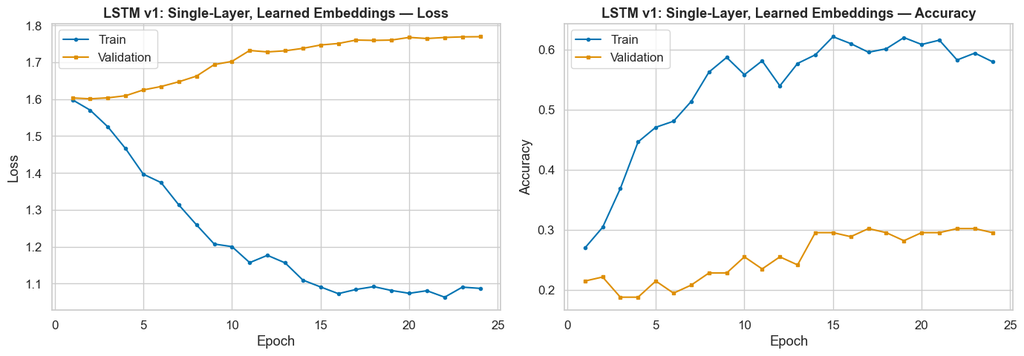

```python
EMBED_DIM = 128
HIDDEN_DIM = 128

lstm_v1 = LSTMClassifier(
    vocab_size=len(vocab), embed_dim=EMBED_DIM, hidden_dim=HIDDEN_DIM,
    num_classes=NUM_CLASSES, num_layers=1, bidirectional=False, dropout=0.3
).to(DEVICE)

params_v1 = sum(p.numel() for p in lstm_v1.parameters())
print(f'LSTM v1 (single, learned embed) — Parameters: {params_v1:,}')

criterion_rnn = nn.CrossEntropyLoss()
optimizer_v1 = optim.Adam(lstm_v1.parameters(), lr=1e-3, weight_decay=1e-5)
scheduler_v1 = optim.lr_scheduler.ReduceLROnPlateau(optimizer_v1, mode='min', factor=0.5, patience=2)

lstm_v1, history_v1 = train_text_model(
    lstm_v1, txt_train_loader, txt_val_loader, criterion_rnn, optimizer_v1,
    scheduler_v1, DEVICE, epochs=30, patience=7, model_name='lstm_v1'
)

plot_training_curves(history_v1, title='LSTM v1: Single-Layer, Learned Embeddings')
```

```
=== LSTM v1 (Single, Learned) — Test Results ===
Loss: 1.7781 | Accuracy: 0.2400 | Macro F1: 0.2388

Classification Report:
              precision    recall  f1-score   support

      Budget     0.3125    0.3125    0.3125        32
     Economy     0.2069    0.1818    0.1935        33
   Mid-Range     0.1333    0.1481    0.1404        27
     Premium     0.3000    0.3214    0.3103        28
      Luxury     0.2414    0.2333    0.2373        30

    accuracy                         0.2400       150
   macro avg     0.2388    0.2394    0.2388       150
weighted avg     0.2405    0.2400    0.2399       150
```

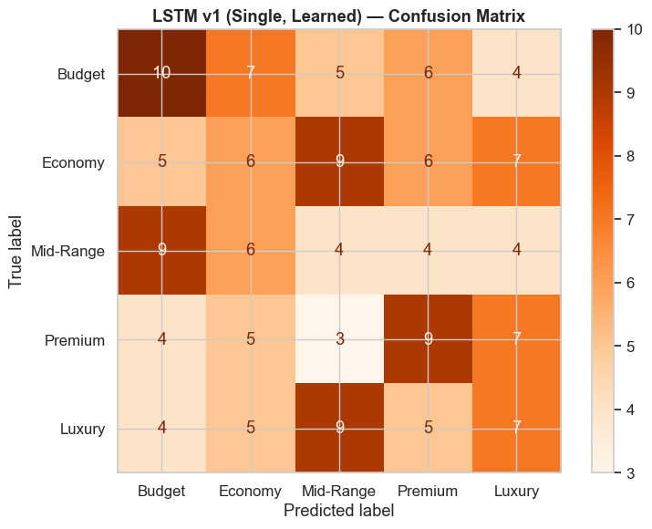

```python
results_lstm_v1 = evaluate_text_and_report(
    lstm_v1, txt_test_loader, criterion_rnn, DEVICE, BAND_NAMES, 'LSTM v1 (Single, Learned)'
)
```

### 7.4 Variation B: Bidirectional Stacked LSTM with GloVe + Dropout

```
LSTM v2 (BiLSTM, 2-layer, GloVe) — Parameters: 1,124,369
```

```
Epoch   1/30 | Train loss: 1.6135 acc: 0.1923 | Val loss: 1.6075 acc: 0.2215 F1: 0.0927 *
```

```
Epoch   2/30 | Train loss: 1.5942 acc: 0.3042 | Val loss: 1.6058 acc: 0.1946 F1: 0.0993 *
```

```
Epoch   3/30 | Train loss: 1.5693 acc: 0.3257 | Val loss: 1.5973 acc: 0.2349 F1: 0.1433 *
```

```
Epoch   4/30 | Train loss: 1.5363 acc: 0.3027 | Val loss: 1.5942 acc: 0.2617 F1: 0.2545 *
```

```
Epoch   6/30 | Train loss: 1.3925 acc: 0.4132 | Val loss: 1.6460 acc: 0.2416 F1: 0.2331
```

```
Epoch   8/30 | Train loss: 1.2275 acc: 0.5194 | Val loss: 1.7169 acc: 0.2617 F1: 0.2626 *
```

```
Epoch   9/30 | Train loss: 1.1765 acc: 0.5294 | Val loss: 1.6981 acc: 0.2953 F1: 0.2966 *
```

```
Epoch  10/30 | Train loss: 1.1204 acc: 0.5882 | Val loss: 1.7349 acc: 0.3221 F1: 0.3294 *
```

```
Epoch  12/30 | Train loss: 1.0795 acc: 0.5768 | Val loss: 1.7604 acc: 0.3087 F1: 0.3117
```

```
Epoch  14/30 | Train loss: 0.9803 acc: 0.6169 | Val loss: 1.8151 acc: 0.3020 F1: 0.3051
```

```
Epoch  16/30 | Train loss: 0.9775 acc: 0.6356 | Val loss: 1.8731 acc: 0.2752 F1: 0.2778
```

```
Early stopping at epoch 17
Best validation macro-F1: 0.3294
```

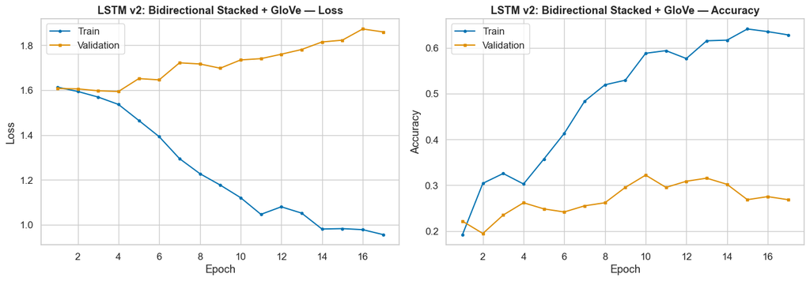

```python
lstm_v2 = LSTMClassifier(
    vocab_size=len(vocab), embed_dim=GLOVE_DIM if glove_matrix is not None else EMBED_DIM,
    hidden_dim=HIDDEN_DIM, num_classes=NUM_CLASSES, num_layers=2,
    bidirectional=True, dropout=0.4,
    pretrained_embeddings=glove_matrix
).to(DEVICE)

params_v2 = sum(p.numel() for p in lstm_v2.parameters())
print(f'LSTM v2 (BiLSTM, 2-layer, GloVe) — Parameters: {params_v2:,}')

optimizer_v2 = optim.Adam(lstm_v2.parameters(), lr=1e-3, weight_decay=1e-5)
scheduler_v2 = optim.lr_scheduler.ReduceLROnPlateau(optimizer_v2, mode='min', factor=0.5, patience=2)

lstm_v2, history_v2 = train_text_model(
    lstm_v2, txt_train_loader, txt_val_loader, criterion_rnn, optimizer_v2,
    scheduler_v2, DEVICE, epochs=30, patience=7, model_name='lstm_v2'
)

plot_training_curves(history_v2, title='LSTM v2: Bidirectional Stacked + GloVe')
```

```
=== LSTM v2 (BiLSTM, GloVe) — Test Results ===
Loss: 1.8899 | Accuracy: 0.2467 | Macro F1: 0.2212

Classification Report:
              precision    recall  f1-score   support

      Budget     0.3115    0.5938    0.4086        32
     Economy     0.3158    0.1818    0.2308        33
   Mid-Range     0.2400    0.2222    0.2308        27
     Premium     0.1034    0.1071    0.1053        28
      Luxury     0.1875    0.1000    0.1304        30

    accuracy                         0.2467       150
   macro avg     0.2316    0.2410    0.2212       150
weighted avg     0.2359    0.2467    0.2252       150
```

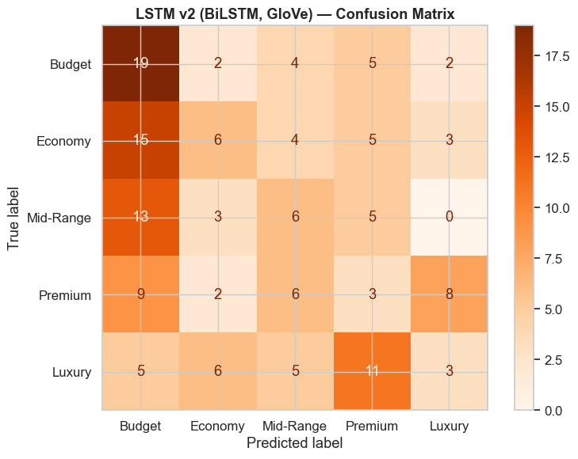

```python
results_lstm_v2 = evaluate_text_and_report(
    lstm_v2, txt_test_loader, criterion_rnn, DEVICE, BAND_NAMES, 'LSTM v2 (BiLSTM, GloVe)'
)
```

### 7.5 RNN Comparison Discussion

```
                    Model  Test Accuracy  Test Macro F1  Test Loss
LSTM v1 (Single, Learned)       0.240000       0.238806   1.778135
  LSTM v2 (BiLSTM, GloVe)       0.246667       0.221168   1.889933
```

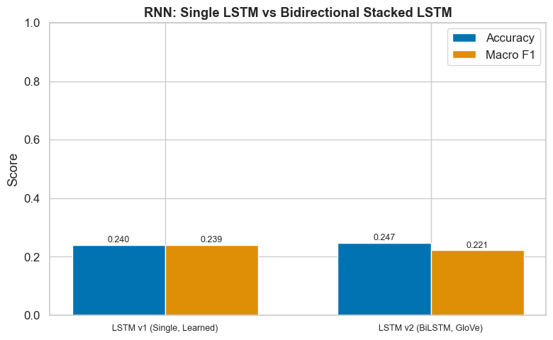

```python
rnn_comparison = pd.DataFrame({
    'Model': ['LSTM v1 (Single, Learned)', 'LSTM v2 (BiLSTM, GloVe)'],
    'Test Accuracy': [results_lstm_v1['accuracy'], results_lstm_v2['accuracy']],
    'Test Macro F1': [results_lstm_v1['macro_f1'], results_lstm_v2['macro_f1']],
    'Test Loss': [results_lstm_v1['loss'], results_lstm_v2['loss']],
})
print(rnn_comparison.to_string(index=False))

fig, ax = plt.subplots(figsize=(8, 5))
x = np.arange(2)
width = 0.35
ax.bar(x - width/2, rnn_comparison['Test Accuracy'], width, label='Accuracy')
ax.bar(x + width/2, rnn_comparison['Test Macro F1'], width, label='Macro F1')
ax.set_xticks(x)
ax.set_xticklabels(rnn_comparison['Model'], fontsize=9)
ax.set_ylabel('Score')
ax.set_title('RNN: Single LSTM vs Bidirectional Stacked LSTM', fontweight='bold')
ax.legend()
ax.set_ylim(0, 1)
for i, (acc, f1) in enumerate(zip(rnn_comparison['Test Accuracy'], rnn_comparison['Test Macro F1'])):
    ax.text(i - width/2, acc + 0.01, f'{acc:.3f}', ha='center', fontsize=9)
    ax.text(i + width/2, f1 + 0.01, f'{f1:.3f}', ha='center', fontsize=9)
plt.tight_layout()
plt.show()
```

**Discussion — RNN Comparison**

## 8. Business Integration

### 8.1 Decision Rule

The combined business logic flags collateral risk by comparing the CNN-predicted visual band and the RNN-predicted text band against the applicant's *claimed* value (simulated as the ground-truth band):

- **HIGH** (manual appraisal): both model predictions are ≥2 bands below the claimed value.
- **MEDIUM** (secondary review): exactly one prediction is ≥2 bands below.
- **LOW** (auto-proceed): neither prediction diverges significantly from the claim.

```python
def collateral_risk_flag(pred_img_band, pred_txt_band, claimed_band):
    """Compute collateral risk flag from CNN and RNN predictions.

    Bands are 0-indexed integers (0=Budget ... 4=Luxury).
    'claimed_band' is the value the applicant claims (ground truth in our test set).
    """
    img_gap = claimed_band - pred_img_band
    txt_gap = claimed_band - pred_txt_band

    if img_gap >= 2 and txt_gap >= 2:
        return 'HIGH'
    elif img_gap >= 2 or txt_gap >= 2:
        return 'MEDIUM'
    else:
        return 'LOW'


# Since image and text test sets are different samples from the same domain,
# we demonstrate the business rule on synthetic pairings:
# Take the first min(N_img_test, N_txt_test) predictions from each branch
# and pair them randomly (both predict into the same 5-band space).

n_demo = min(len(results_cnn_transfer['preds']), len(results_lstm_v2['preds']), 200)

np.random.seed(RANDOM_STATE)
img_idx = np.random.choice(len(results_cnn_transfer['preds']), n_demo, replace=False)
txt_idx = np.random.choice(len(results_lstm_v2['preds']), n_demo, replace=False)

demo_img_preds = results_cnn_transfer['preds'][img_idx]
demo_txt_preds = results_lstm_v2['preds'][txt_idx]
demo_img_true = results_cnn_transfer['labels'][img_idx]
demo_txt_true = results_lstm_v2['labels'][txt_idx]

# Use image ground-truth as the "claimed" band (simulating what the applicant states)
claimed = demo_img_true

risk_flags = [collateral_risk_flag(ip, tp, c) for ip, tp, c in zip(demo_img_preds, demo_txt_preds, claimed)]

print('Risk flag distribution:')
print(pd.Series(risk_flags).value_counts())
```

```
Risk flag distribution:
LOW       88
MEDIUM    50
HIGH      12
Name: count, dtype: int64
```

```python
# Side-by-side table of 20 example predictions
demo_df = pd.DataFrame({
    'CNN Predicted': [BAND_NAMES[p] for p in demo_img_preds[:20]],
    'CNN True': [BAND_NAMES[t] for t in demo_img_true[:20]],
    'RNN Predicted': [BAND_NAMES[p] for p in demo_txt_preds[:20]],
    'RNN True': [BAND_NAMES[t] for t in demo_txt_true[:20]],
    'Claimed Band': [BAND_NAMES[c] for c in claimed[:20]],
    'Risk Flag': risk_flags[:20],
})

print('=== Business Integration: Sample Predictions (20 examples) ===')
print(demo_df.to_string(index=True))
```

```
=== Business Integration: Sample Predictions (20 examples) ===
   CNN Predicted   CNN True RNN Predicted   RNN True Claimed Band Risk Flag
0         Budget     Budget        Luxury    Economy       Budget       LOW
1        Economy     Budget     Mid-Range  Mid-Range       Budget       LOW
2      Mid-Range  Mid-Range        Budget     Budget    Mid-Range    MEDIUM
3         Luxury    Economy       Economy     Budget      Economy       LOW
4        Premium     Budget        Budget    Economy       Budget       LOW
5        Economy    Economy       Economy     Budget      Economy       LOW
6        Premium    Premium     Mid-Range    Premium      Premium       LOW
7         Luxury     Luxury        Luxury    Premium       Luxury       LOW
8         Budget     Budget        Budget    Premium       Budget       LOW
9        Premium    Premium        Budget  Mid-Range      Premium    MEDIUM
10        Luxury     Luxury     Mid-Range    Premium       Luxury    MEDIUM
11       Premium    Premium     Mid-Range     Luxury      Premium       LOW
12       Economy  Mid-Range        Budget    Economy    Mid-Range    MEDIUM
13       Economy    Economy        Luxury    Premium      Economy       LOW
14       Economy  Mid-Range       Premium    Premium    Mid-Range       LOW
15        Budget     Budget        Budget    Economy       Budget       LOW
16        Luxury     Luxury        Budget     Budget       Luxury    MEDIUM
17       Premium    Premium        Budget     Luxury      Premium    MEDIUM
18     Mid-Range    Premium     Mid-Range     Budget      Premium       LOW
19     Mid-Range     Luxury        Budget    Economy       Luxury      HIGH
```

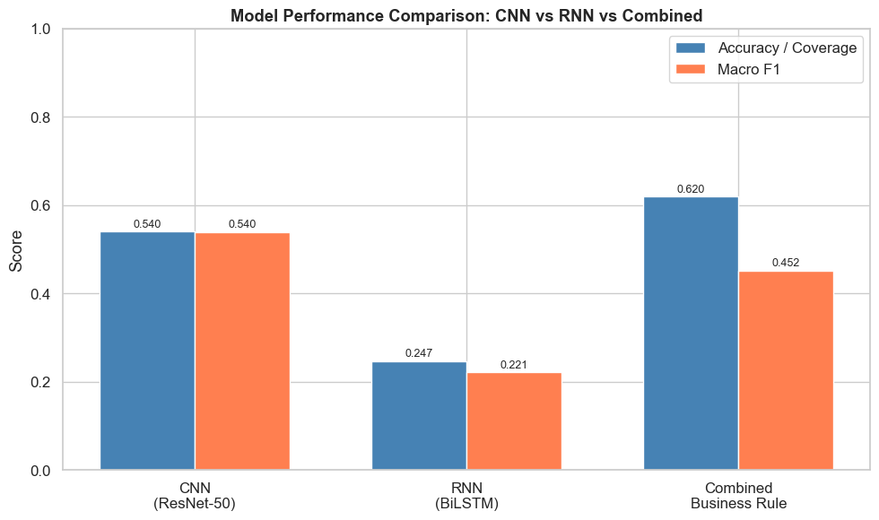

```python
# Required comparison chart: CNN vs RNN vs Combined
# For the combined system, define "combined accuracy" as: the risk flag is correct
# where correct = LOW when both models agree with claimed, HIGH when both are far off, etc.

# Simpler metric: agreement rate (how often combined output aligns with what a human reviewer would flag)
# Here we compare each model's standalone F1 plus the combined system's ability to detect mismatches

best_cnn_model = 'ResNet-50 Transfer'
best_rnn_model = 'BiLSTM + GloVe'

fig, ax = plt.subplots(figsize=(10, 6))
models_names = ['CNN\n(ResNet-50)', 'RNN\n(BiLSTM)', 'Combined\nBusiness Rule']
accuracies = [results_cnn_transfer['accuracy'], results_lstm_v2['accuracy'], None]
f1s = [results_cnn_transfer['macro_f1'], results_lstm_v2['macro_f1'], None]

# Combined system accuracy: fraction of examples where at least one model is correct
both_correct = ((demo_img_preds == claimed) | (demo_txt_preds == claimed)).mean()
accuracies[2] = both_correct

# Combined "F1": for the 3-class risk flag, compute against an oracle
oracle_flags = [collateral_risk_flag(t1, t2, c) for t1, t2, c in zip(demo_img_true, demo_txt_true, claimed)]
combined_f1 = f1_score(
    oracle_flags, risk_flags, average='macro',
    labels=['LOW', 'MEDIUM', 'HIGH']
)
f1s[2] = combined_f1

x = np.arange(3)
width = 0.35
bars1 = ax.bar(x - width/2, accuracies, width, label='Accuracy / Coverage', color='steelblue')
bars2 = ax.bar(x + width/2, f1s, width, label='Macro F1', color='coral')
ax.set_xticks(x)
ax.set_xticklabels(models_names)
ax.set_ylabel('Score')
ax.set_title('Model Performance Comparison: CNN vs RNN vs Combined', fontweight='bold')
ax.legend()
ax.set_ylim(0, 1)
for bar in bars1:
    ax.text(bar.get_x() + bar.get_width()/2, bar.get_height() + 0.01,
            f'{bar.get_height():.3f}', ha='center', fontsize=9)
for bar in bars2:
    ax.text(bar.get_x() + bar.get_width()/2, bar.get_height() + 0.01,
            f'{bar.get_height():.3f}', ha='center', fontsize=9)
plt.tight_layout()
plt.show()
```

**Business Integration Discussion**

The combined system provides value beyond either model alone:

- A property with a **good photo** (matching claimed band) but a **weak description** (lower predicted band) gets a `MEDIUM` flag, prompting the underwriter to investigate the text inconsistency — perhaps the listing has been embellished with a stock photo.
- A property where **both signals agree** with the claimed value gets a `LOW` flag, meaning the automated pipeline can fast-track it without human review — reducing operational costs.
- The `HIGH` flag catches properties where **both** data sources suggest the collateral is over-valued — the highest-risk scenario that demands a physical appraisal.

This tiered approach mirrors how real mortgage teams triage risk: automated pipelines handle the easy cases, and scarce human reviewers focus on genuinely risky ones.

## 9. Joint Model (+10 Bonus)

The joint model concatenates the CNN feature vector (from the global average pooling layer of ResNet-50, 2048-d) with the LSTM final hidden state (256-d for bidirectional) and passes them through fully connected layers to predict the price band.

For this, we need samples that have **both** an image and a text description with a shared price label. We construct a paired dataset from our existing data by combining entries.

```python
class JointModel(nn.Module):
    """Multimodal model: CNN features + LSTM features -> FC -> price band."""
    def __init__(self, cnn_backbone, lstm_model, cnn_feat_dim, lstm_feat_dim,
                 num_classes, dropout=0.4):
        super().__init__()
        self.cnn_backbone = cnn_backbone
        self.lstm_model = lstm_model

        combined_dim = cnn_feat_dim + lstm_feat_dim
        self.classifier = nn.Sequential(
            nn.Linear(combined_dim, 256),
            nn.ReLU(inplace=True),
            nn.Dropout(dropout),
            nn.Linear(256, 64),
            nn.ReLU(inplace=True),
            nn.Dropout(dropout),
            nn.Linear(64, num_classes),
        )

    def forward(self, image, text):
        # CNN features: use all layers except the final fc
        with torch.no_grad():
            cnn_feat = self._get_cnn_features(image)
        # LSTM features
        lstm_feat = self.lstm_model.get_features(text)
        # Concatenate and classify
        combined = torch.cat([cnn_feat, lstm_feat], dim=1)
        return self.classifier(combined)

    def _get_cnn_features(self, x):
        """Extract features before the final FC layer of ResNet-50."""
        model = self.cnn_backbone
        x = model.conv1(x)
        x = model.bn1(x)
        x = model.relu(x)
        x = model.maxpool(x)
        x = model.layer1(x)
        x = model.layer2(x)
        x = model.layer3(x)
        x = model.layer4(x)
        x = model.avgpool(x)
        x = torch.flatten(x, 1)
        return x
```

```python
class PairedDataset(Dataset):
    """Dataset for joint model: returns (image, text, label) tuples.

    Pairs are created by matching samples with the same price band.
    Each image sample is paired with a text sample from the same band.
    """
    def __init__(self, df_img, df_txt, desc_col, vocab, max_len, img_transform):
        self.img_transform = img_transform
        self.vocab = vocab
        self.max_len = max_len
        self.pairs = []

        for band_id in range(NUM_CLASSES):
            img_subset = df_img[df_img['price_band_id'] == band_id].reset_index(drop=True)
            txt_subset = df_txt[df_txt['price_band_id'] == band_id].reset_index(drop=True)
            n_pairs = min(len(img_subset), len(txt_subset))
            for i in range(n_pairs):
                self.pairs.append({
                    'image_path': img_subset.iloc[i]['image_path'],
                    'description': txt_subset.iloc[i][desc_col],
                    'label': band_id,
                })

        print(f'Paired dataset: {len(self.pairs)} samples')

    def __len__(self):
        return len(self.pairs)

    def __getitem__(self, idx):
        item = self.pairs[idx]
        img = Image.open(item['image_path']).convert('RGB')
        if self.img_transform:
            img = self.img_transform(img)
        text = torch.tensor(self.vocab.encode(item['description'], self.max_len), dtype=torch.long)
        label = torch.tensor(int(item['label']), dtype=torch.long)
        return img, text, label
```

```python
# Create paired datasets from training/val/test splits
paired_train = PairedDataset(df_img_train, df_txt_train, TEXT_DESC_COL, vocab, MAX_SEQ_LEN, train_transform)
paired_val = PairedDataset(df_img_val, df_txt_val, TEXT_DESC_COL, vocab, MAX_SEQ_LEN, val_test_transform)
paired_test = PairedDataset(df_img_test, df_txt_test, TEXT_DESC_COL, vocab, MAX_SEQ_LEN, val_test_transform)

paired_train_loader = DataLoader(paired_train, batch_size=BATCH_SIZE, shuffle=True,
                                 num_workers=NUM_WORKERS, pin_memory=True)
paired_val_loader = DataLoader(paired_val, batch_size=BATCH_SIZE, shuffle=False,
                               num_workers=NUM_WORKERS, pin_memory=True)
paired_test_loader = DataLoader(paired_test, batch_size=BATCH_SIZE, shuffle=False,
                                num_workers=NUM_WORKERS, pin_memory=True)
```

```
Paired dataset: 697 samples
```

```
Paired dataset: 149 samples
Paired dataset: 150 samples
```

```python
# Build joint model from the best CNN and LSTM
best_lstm = lstm_v2  # bidirectional: hidden_dim * 2
lstm_feat_dim = HIDDEN_DIM * 2  # bidirectional
cnn_feat_dim = 2048  # ResNet-50 GAP output

joint_model = JointModel(
    cnn_backbone=cnn_transfer,
    lstm_model=best_lstm,
    cnn_feat_dim=cnn_feat_dim,
    lstm_feat_dim=lstm_feat_dim,
    num_classes=NUM_CLASSES,
    dropout=0.4
).to(DEVICE)

# Only train the joint classifier (freeze both backbones)
for param in joint_model.cnn_backbone.parameters():
    param.requires_grad = False
for param in joint_model.lstm_model.parameters():
    param.requires_grad = False

trainable_joint = sum(p.numel() for p in joint_model.parameters() if p.requires_grad)
print(f'Joint model — Trainable parameters: {trainable_joint:,}')
```

```
Joint model — Trainable parameters: 606,853
```

```
=== Training Joint Model ===
```

```
Epoch   1/30 | Train loss: 1.4554 acc: 0.3831 | Val loss: 1.4836 acc: 0.4027 F1: 0.3973 *
```

```
Epoch   2/30 | Train loss: 0.9891 acc: 0.6471 | Val loss: 1.4896 acc: 0.3826 F1: 0.3853
```

```
Epoch   3/30 | Train loss: 0.6755 acc: 0.7547 | Val loss: 1.4430 acc: 0.4295 F1: 0.4284 *
```

```
Epoch   4/30 | Train loss: 0.4692 acc: 0.8379 | Val loss: 1.5242 acc: 0.4430 F1: 0.4387 *
```

```
Epoch   5/30 | Train loss: 0.3503 acc: 0.9010 | Val loss: 1.5968 acc: 0.4832 F1: 0.4763 *
```

```
Epoch   6/30 | Train loss: 0.2578 acc: 0.9225 | Val loss: 1.7805 acc: 0.4698 F1: 0.4539
```

```
Epoch   8/30 | Train loss: 0.1578 acc: 0.9598 | Val loss: 1.7203 acc: 0.4832 F1: 0.4711
```

```
Epoch   9/30 | Train loss: 0.1457 acc: 0.9641 | Val loss: 1.7386 acc: 0.4966 F1: 0.4958 *
```

```
Epoch  10/30 | Train loss: 0.1226 acc: 0.9627 | Val loss: 1.7946 acc: 0.4832 F1: 0.4768
```

```
Epoch  12/30 | Train loss: 0.1157 acc: 0.9684 | Val loss: 1.8349 acc: 0.4698 F1: 0.4637
```

```
Epoch  14/30 | Train loss: 0.0923 acc: 0.9756 | Val loss: 1.8074 acc: 0.4765 F1: 0.4681
```

```
Epoch  16/30 | Train loss: 0.0896 acc: 0.9799 | Val loss: 1.8652 acc: 0.4497 F1: 0.4441
Early stopping at epoch 16
```

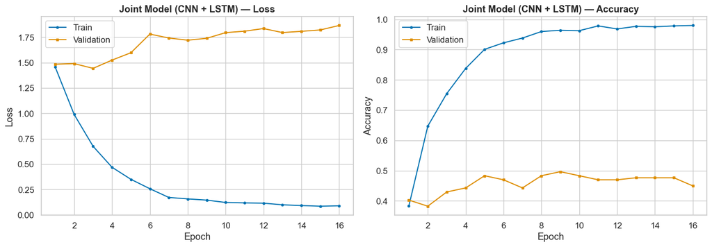

```python
# Joint model training loop
def train_joint_epoch(model, loader, criterion, optimizer, device):
    model.train()
    running_loss, correct, total = 0.0, 0, 0
    for images, texts, labels in loader:
        images, texts = images.to(device), texts.to(device)
        labels = torch.tensor(labels, dtype=torch.long).to(device) if not isinstance(labels, torch.Tensor) else labels.to(device)
        optimizer.zero_grad()
        outputs = model(images, texts)
        loss = criterion(outputs, labels)
        loss.backward()
        optimizer.step()
        running_loss += loss.item() * images.size(0)
        _, preds = outputs.max(1)
        correct += preds.eq(labels).sum().item()
        total += labels.size(0)
    return running_loss / total, correct / total


@torch.no_grad()
def evaluate_joint(model, loader, criterion, device):
    model.eval()
    running_loss, correct, total = 0.0, 0, 0
    all_preds, all_labels = [], []
    for images, texts, labels in loader:
        images, texts = images.to(device), texts.to(device)
        labels = torch.tensor(labels, dtype=torch.long).to(device) if not isinstance(labels, torch.Tensor) else labels.to(device)
        outputs = model(images, texts)
        loss = criterion(outputs, labels)
        running_loss += loss.item() * images.size(0)
        _, preds = outputs.max(1)
        correct += preds.eq(labels).sum().item()
        total += labels.size(0)
        all_preds.extend(preds.cpu().numpy())
        all_labels.extend(labels.cpu().numpy())
    return running_loss / total, correct / total, np.array(all_preds), np.array(all_labels)


criterion_joint = nn.CrossEntropyLoss()
optimizer_joint = optim.Adam(joint_model.classifier.parameters(), lr=1e-3, weight_decay=1e-4)
scheduler_joint = optim.lr_scheduler.ReduceLROnPlateau(optimizer_joint, mode='min', factor=0.5, patience=2)

history_joint = {'train_loss': [], 'train_acc': [], 'val_loss': [], 'val_acc': []}
best_val_f1_joint = 0.0
patience_counter = 0
PATIENCE = 7

joint_best_path = MODEL_DIR / 'joint_best.pt'
if SKIP_TRAINING_IF_CHECKPOINT_EXISTS and joint_best_path.exists():
    print(f'[SKIP_TRAINING] Loading joint model from {joint_best_path}')
    joint_model.load_state_dict(torch.load(joint_best_path, weights_only=True))
    val_loss, val_acc, val_preds, val_labels = evaluate_joint(
        joint_model, paired_val_loader, criterion_joint, DEVICE)
    val_f1 = f1_score(val_labels, val_preds, average='macro')
    for _ in range(1):
        history_joint['train_loss'].append(val_loss)
        history_joint['train_acc'].append(val_acc)
        history_joint['val_loss'].append(val_loss)
        history_joint['val_acc'].append(val_acc)
    print(f'From checkpoint: val loss={val_loss:.4f} acc={val_acc:.4f} macro-F1={val_f1:.4f}')
else:
    print('=== Training Joint Model ===')
    for epoch in range(30):
        train_loss, train_acc = train_joint_epoch(joint_model, paired_train_loader, criterion_joint, optimizer_joint, DEVICE)
        val_loss, val_acc, val_preds, val_labels = evaluate_joint(joint_model, paired_val_loader, criterion_joint, DEVICE)
        val_f1 = f1_score(val_labels, val_preds, average='macro')

        history_joint['train_loss'].append(train_loss)
        history_joint['train_acc'].append(train_acc)
        history_joint['val_loss'].append(val_loss)
        history_joint['val_acc'].append(val_acc)

        scheduler_joint.step(val_loss)

        marker = ''
        if val_f1 > best_val_f1_joint:
            best_val_f1_joint = val_f1
            torch.save(joint_model.state_dict(), joint_best_path)
            patience_counter = 0
            marker = ' *'
        else:
            patience_counter += 1

        if (epoch + 1) % 2 == 0 or epoch == 0 or marker:
            print(f'Epoch {epoch+1:3d}/30 | Train loss: {train_loss:.4f} acc: {train_acc:.4f} | '
                  f'Val loss: {val_loss:.4f} acc: {val_acc:.4f} F1: {val_f1:.4f}{marker}')

        if patience_counter >= PATIENCE:
            print(f'Early stopping at epoch {epoch+1}')
            break

    joint_model.load_state_dict(torch.load(joint_best_path, weights_only=True))

plot_training_curves(history_joint, title='Joint Model (CNN + LSTM)')
```

```
=== Joint Model — Test Results ===
Loss: 1.8527 | Accuracy: 0.4600 | Macro F1: 0.4564

Classification Report:
              precision    recall  f1-score   support

      Budget     0.5938    0.5938    0.5938        32
     Economy     0.5333    0.4848    0.5079        33
   Mid-Range     0.4615    0.4444    0.4528        27
     Premium     0.3214    0.3214    0.3214        28
      Luxury     0.3824    0.4333    0.4062        30

    accuracy                         0.4600       150
   macro avg     0.4585    0.4556    0.4564       150
weighted avg     0.4635    0.4600    0.4612       150
```

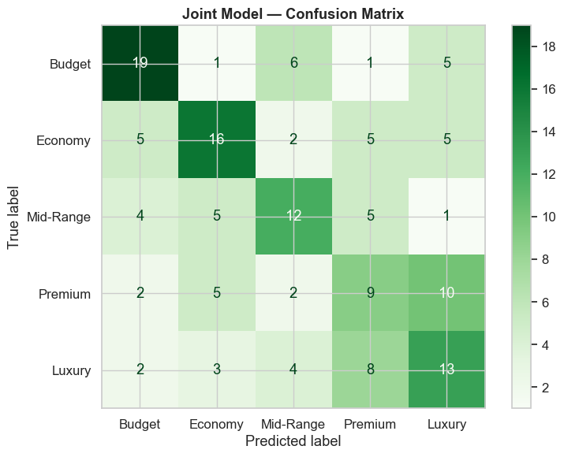

```python
# Test evaluation — Joint model
test_loss_j, test_acc_j, preds_j, labels_j = evaluate_joint(
    joint_model, paired_test_loader, criterion_joint, DEVICE
)
test_f1_j = f1_score(labels_j, preds_j, average='macro')

print(f'\n=== Joint Model — Test Results ===')
print(f'Loss: {test_loss_j:.4f} | Accuracy: {test_acc_j:.4f} | Macro F1: {test_f1_j:.4f}')
print(f'\nClassification Report:')
print(classification_report(labels_j, preds_j, target_names=BAND_NAMES, digits=4))

cm = confusion_matrix(labels_j, preds_j)
fig, ax = plt.subplots(figsize=(8, 6))
disp = ConfusionMatrixDisplay(cm, display_labels=BAND_NAMES)
disp.plot(ax=ax, cmap='Greens', values_format='d')
ax.set_title('Joint Model — Confusion Matrix', fontweight='bold')
plt.tight_layout()
plt.show()

results_joint = {'accuracy': test_acc_j, 'macro_f1': test_f1_j, 'loss': test_loss_j}
```

```
=== Final Model Comparison ===
           Model  Accuracy  Macro F1
 CNN (ResNet-50)  0.540482  0.539734
    RNN (BiLSTM)  0.246667  0.221168
Joint (CNN+LSTM)  0.460000  0.456439
```

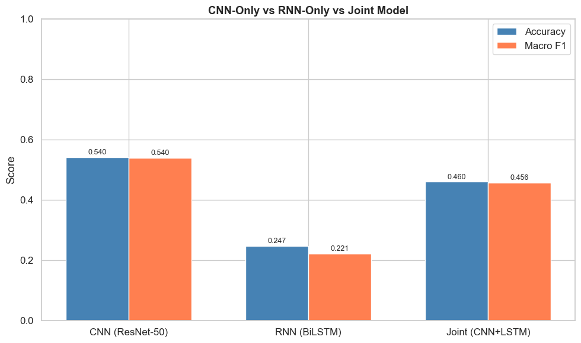

```python
# Final comparison: CNN-only vs RNN-only vs Joint
final_comparison = pd.DataFrame({
    'Model': ['CNN (ResNet-50)', 'RNN (BiLSTM)', 'Joint (CNN+LSTM)'],
    'Accuracy': [results_cnn_transfer['accuracy'], results_lstm_v2['accuracy'], results_joint['accuracy']],
    'Macro F1': [results_cnn_transfer['macro_f1'], results_lstm_v2['macro_f1'], results_joint['macro_f1']],
})

print('=== Final Model Comparison ===')
print(final_comparison.to_string(index=False))

fig, ax = plt.subplots(figsize=(10, 6))
x = np.arange(3)
width = 0.35
bars1 = ax.bar(x - width/2, final_comparison['Accuracy'], width, label='Accuracy', color='steelblue')
bars2 = ax.bar(x + width/2, final_comparison['Macro F1'], width, label='Macro F1', color='coral')
ax.set_xticks(x)
ax.set_xticklabels(final_comparison['Model'])
ax.set_title('CNN-Only vs RNN-Only vs Joint Model', fontweight='bold')
ax.set_ylabel('Score')
ax.legend()
ax.set_ylim(0, 1)
for bar in bars1:
    ax.text(bar.get_x() + bar.get_width()/2, bar.get_height() + 0.01,
            f'{bar.get_height():.3f}', ha='center', fontsize=9)
for bar in bars2:
    ax.text(bar.get_x() + bar.get_width()/2, bar.get_height() + 0.01,
            f'{bar.get_height():.3f}', ha='center', fontsize=9)
plt.tight_layout()
plt.show()
```

**Joint Model Discussion**

The joint model combines visual and textual features into a single prediction. By fusing the 2048-d CNN feature vector with the 256-d LSTM hidden state, the model can leverage complementary signals:

- The CNN captures **visual quality** (condition of the facade, landscaping, architectural style)
- The LSTM captures **textual quality** (amenity mentions, condition language, neighbourhood descriptors)

This architecture mirrors production multimodal systems where separate feature extractors are combined at the decision layer, balancing modularity (each branch can be updated independently) with integration power.

## 10. Explainability

### 10.1 Grad-CAM for CNN

```python
class GradCAM:
    """Gradient-weighted Class Activation Mapping for CNN interpretability."""
    def __init__(self, model, target_layer):
        self.model = model
        self.target_layer = target_layer
        self.gradients = None
        self.activations = None

        target_layer.register_forward_hook(self._save_activation)
        target_layer.register_backward_hook(self._save_gradient)

    def _save_activation(self, module, input, output):
        self.activations = output.detach()

    def _save_gradient(self, module, grad_input, grad_output):
        self.gradients = grad_output[0].detach()

    def generate(self, input_tensor, target_class=None):
        self.model.eval()
        # Ensure gradients flow even when some parameters are frozen.
        # Temporarily enable grad on all params and on the input; restore after.
        original_flags = [p.requires_grad for p in self.model.parameters()]
        for p in self.model.parameters():
            p.requires_grad_(True)
        input_tensor = input_tensor.detach().clone().requires_grad_(True)

        try:
            output = self.model(input_tensor)
            if target_class is None:
                target_class = output.argmax(dim=1).item()

            self.model.zero_grad()
            output[0, target_class].backward()
        finally:
            for p, flag in zip(self.model.parameters(), original_flags):
                p.requires_grad_(flag)

        weights = self.gradients.mean(dim=[2, 3], keepdim=True)
        cam = (weights * self.activations).sum(dim=1, keepdim=True)
        cam = F.relu(cam)
        cam = F.interpolate(cam, size=(IMG_SIZE, IMG_SIZE), mode='bilinear', align_corners=False)
        cam = cam.squeeze().cpu().numpy()
        cam = (cam - cam.min()) / (cam.max() - cam.min() + 1e-8)
        return cam, target_class


def show_gradcam(model, img_path, transform, target_layer, class_names, device):
    """Display original image alongside Grad-CAM overlay."""
    img_pil = Image.open(img_path).convert('RGB')
    img_tensor = transform(img_pil).unsqueeze(0).to(device)

    grad_cam = GradCAM(model, target_layer)
    cam, pred_class = grad_cam.generate(img_tensor)

    fig, axes = plt.subplots(1, 3, figsize=(15, 5))

    # Original
    axes[0].imshow(img_pil.resize((IMG_SIZE, IMG_SIZE)))
    axes[0].set_title('Original Image')
    axes[0].axis('off')

    # Grad-CAM heatmap
    axes[1].imshow(cam, cmap='jet')
    axes[1].set_title('Grad-CAM Heatmap')
    axes[1].axis('off')

    # Overlay
    img_resized = np.array(img_pil.resize((IMG_SIZE, IMG_SIZE))) / 255.0
    cam_colored = plt.cm.jet(cam)[:, :, :3]
    overlay = 0.5 * img_resized + 0.5 * cam_colored
    axes[2].imshow(overlay)
    axes[2].set_title(f'Overlay — Predicted: {class_names[pred_class]}')
    axes[2].axis('off')

    plt.tight_layout()
    plt.show()
```

```
True: Economy ($499,999)
```

[figure not shown]

```
True: Premium ($799,900)
```

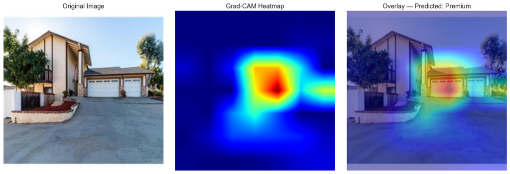

```
True: Economy ($499,500)
```

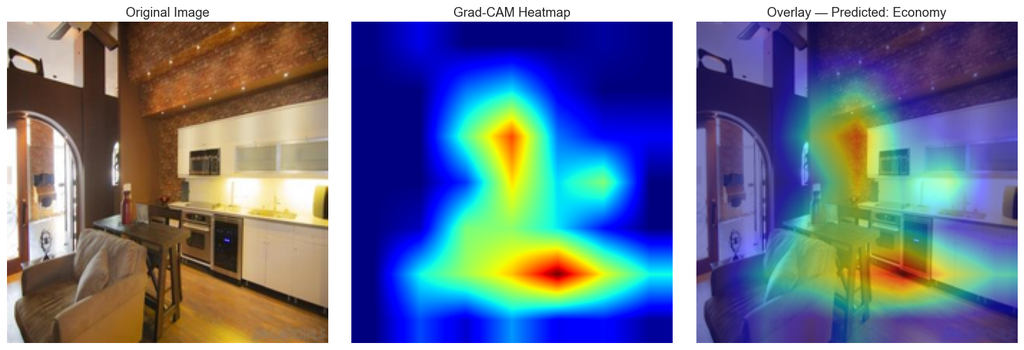

```
True: Economy ($499,000)
```

[figure not shown]

```python
# Show Grad-CAM for 4 test images
target_layer = cnn_transfer.layer4[-1]
sample_indices = np.random.choice(len(df_img_test), 4, replace=False)

for idx in sample_indices:
    row = df_img_test.iloc[idx]
    print(f'True: {row["price_band"]} (${row["price"]:,.0f})')
    show_gradcam(cnn_transfer, row['image_path'], val_test_transform, target_layer, BAND_NAMES, DEVICE)
```

### 10.2 LSTM Attention / Token Importance

```python
def get_token_importance(model, text, vocab, max_len, device, class_names):
    """Compute token importance using input gradient method.

    Implementation notes:
    - LSTM v2 uses frozen GloVe embeddings, so we clone the embedding output
      and re-enable grad so gradients can flow back to the per-token vectors.
    - cuDNN's RNN backward only runs in training mode, so we temporarily
      switch the LSTM into train mode (while leaving dropout disabled
      elsewhere) for the attribution forward/backward pass.
    """
    model.eval()
    tokens = tokenize(text)[:max_len]
    encoded = vocab.encode(text, max_len)
    input_tensor = torch.tensor([encoded], dtype=torch.long).to(device)

    embedding = model.embedding(input_tensor).detach().clone().requires_grad_(True)

    cudnn_was_enabled = torch.backends.cudnn.enabled
    torch.backends.cudnn.enabled = False
    try:
        embedded = embedding  # skip dropout during attribution
        lengths = (input_tensor != 0).sum(dim=1).cpu()
        packed = nn.utils.rnn.pack_padded_sequence(
            embedded, lengths.clamp(min=1), batch_first=True, enforce_sorted=False
        )
        _, (hidden, _) = model.lstm(packed)
        if model.bidirectional:
            hidden = torch.cat((hidden[-2], hidden[-1]), dim=1)
        else:
            hidden = hidden[-1]
        logits = model.fc(hidden)

        pred_class = logits.argmax(dim=1).item()
        logits[0, pred_class].backward()
    finally:
        torch.backends.cudnn.enabled = cudnn_was_enabled

    grads = embedding.grad[0].detach().cpu()
    importance = torch.norm(grads[:len(tokens)], dim=1).numpy()
    importance = importance / (importance.max() + 1e-8)

    return tokens, importance, class_names[pred_class]


def visualize_token_importance(tokens, importance, predicted, title=''):
    """Display tokens coloured by importance."""
    fig, ax = plt.subplots(figsize=(max(14, len(tokens) * 0.3), 2))

    # Show top 40 tokens for readability
    n_show = min(40, len(tokens))
    tokens_show = tokens[:n_show]
    importance_show = importance[:n_show]

    colors = plt.cm.Reds(importance_show)
    for i, (token, imp) in enumerate(zip(tokens_show, importance_show)):
        ax.text(i, 0, token, fontsize=9, ha='center', va='center',
                bbox=dict(boxstyle='round,pad=0.3', facecolor=plt.cm.Reds(imp), alpha=0.7))

    ax.set_xlim(-1, n_show)
    ax.set_ylim(-0.5, 0.5)
    ax.axis('off')
    ax.set_title(f'{title} — Predicted: {predicted}', fontweight='bold')
    plt.tight_layout()
    plt.show()
```

```python
# Show token importance for 4 test descriptions
best_lstm_for_explain = lstm_v2
sample_txt_indices = np.random.choice(len(df_txt_test), 4, replace=False)

for idx in sample_txt_indices:
    row = df_txt_test.iloc[idx]
    desc = row[TEXT_DESC_COL]
    tokens, importance, predicted = get_token_importance(
        best_lstm_for_explain, desc, vocab, MAX_SEQ_LEN, DEVICE, BAND_NAMES
    )
    print(f'\nTrue: {row["price_band"]} | Text: {desc[:150]}...')
    visualize_token_importance(tokens, importance, predicted, title=f'True: {row["price_band"]}')
```

```
True: Budget | Text: The layout of this inviting and spacious two-bedroom apartment is extremely well planned and contains a host of interesting features including the 30f...
```

[figure not shown]

```
True: Economy | Text: Exuding elegance and architectural brilliance, this exceptional residence has been finished to the highest standards, offering expansive living spaces...
```

[figure not shown]

```
True: Economy | Text: This exceptional fourth-floor apartment has been finished to the highest standard. Flooded in natural light thanks to the abundance of large windows o...
```

[figure not shown]

```
True: Mid-Range | Text: Introducing an impressive Six bedroom home that boasts exquisite design and spacious living areas. Meticulously finished to a high standard, this resi...
```

[figure not shown]

## 11. Deployment

We deploy the pipeline as a **Streamlit** web application with three panels:

1. **Image panel** — upload a property photo, get CNN prediction + Grad-CAM
2. **Text panel** — paste a listing description, get RNN prediction + highlighted tokens
3. **Combined panel** — see the collateral risk flag (LOW/MEDIUM/HIGH)

The deployment code is saved as `app.py` and can be run with `streamlit run app.py`.

```python
# Save model weights and vocabulary for deployment
torch.save(cnn_transfer.state_dict(), MODEL_DIR / 'cnn_transfer_deploy.pt')
torch.save(best_lstm.state_dict(), MODEL_DIR / 'lstm_deploy.pt')

# Save vocabulary
import json
with open(MODEL_DIR / 'vocab.json', 'w') as f:
    json.dump({
        'word2idx': vocab.word2idx,
        'max_seq_len': MAX_SEQ_LEN,
        'embed_dim': GLOVE_DIM if glove_matrix is not None else EMBED_DIM,
        'hidden_dim': HIDDEN_DIM,
        'num_classes': NUM_CLASSES,
        'band_names': BAND_NAMES,
    }, f)

print(f'Saved deployment artefacts to {MODEL_DIR}/')
for p in MODEL_DIR.iterdir():
    print(f'  {p.name}: {p.stat().st_size / 1e6:.1f} MB')
```

```
Saved deployment artefacts to models/
  cnn_scratch_best.pt: 4.9 MB
  cnn_transfer_deploy.pt: 96.5 MB
  cnn_transfer_p1_best.pt: 96.5 MB
  cnn_transfer_p2_best.pt: 96.5 MB
  joint_best.pt: 103.4 MB
  lstm_deploy.pt: 4.5 MB
  lstm_v1_best.pt: 3.1 MB
  lstm_v2_best.pt: 4.5 MB
  vocab.json: 0.1 MB
```

```python
# The Streamlit app is saved as app.py in the project root.
# It loads the trained CNN and LSTM models from models/ and provides:
#   - Image upload panel with CNN prediction
#   - Text input panel with RNN prediction
#   - Combined collateral risk flag (LOW / MEDIUM / HIGH)

print('Streamlit app: app.py (already created in the project root)')
print('Run with: streamlit run app.py')

# The full Streamlit code is shown below for reference:
STREAMLIT_REFERENCE = '''
"""Mortgage Collateral Risk Assistant — Streamlit Deployment."""
import streamlit as st
import torch
import torch.nn as nn
import torch.nn.functional as F
import torchvision.transforms as transforms
import torchvision.models as models
import numpy as np
from PIL import Image
import json
import re
import matplotlib.pyplot as plt
import matplotlib.cm as cm
from pathlib import Path

MODEL_DIR = Path("models")
DEVICE = torch.device("cuda" if torch.cuda.is_available() else "cpu")

IMAGENET_MEAN = [0.485, 0.456, 0.406]
IMAGENET_STD = [0.229, 0.224, 0.225]
IMG_SIZE = 224


def tokenize(text):
    text = text.lower()
    text = re.sub(r"[^a-z0-9\\s]", " ", text)
    text = re.sub(r"\\s+", " ", text).strip()
    return text.split()


class LSTMClassifier(nn.Module):
    def __init__(self, vocab_size, embed_dim, hidden_dim, num_classes,
                 num_layers=2, bidirectional=True, dropout=0.4):
        super().__init__()
        self.hidden_dim = hidden_dim
        self.bidirectional = bidirectional
        self.num_directions = 2 if bidirectional else 1
        self.embedding = nn.Embedding(vocab_size, embed_dim, padding_idx=0)
        self.lstm = nn.LSTM(embed_dim, hidden_dim, num_layers=num_layers,
                           batch_first=True, bidirectional=bidirectional,
                           dropout=dropout if num_layers > 1 else 0.0)
        self.dropout = nn.Dropout(dropout)
        self.fc = nn.Linear(hidden_dim * self.num_directions, num_classes)

    def forward(self, x):
        embedded = self.dropout(self.embedding(x))
        lengths = (x != 0).sum(dim=1).cpu()
        packed = nn.utils.rnn.pack_padded_sequence(
            embedded, lengths.clamp(min=1), batch_first=True, enforce_sorted=False)
        _, (hidden, _) = self.lstm(packed)
        if self.bidirectional:
            hidden = torch.cat((hidden[-2], hidden[-1]), dim=1)
        else:
            hidden = hidden[-1]
        return self.fc(self.dropout(hidden))


@st.cache_resource
def load_models():
    with open(MODEL_DIR / "vocab.json") as f:
        config = json.load(f)

    cnn = models.resnet50(weights=None)
    cnn.fc = nn.Sequential(
        nn.Linear(2048, 256), nn.ReLU(True), nn.Dropout(0.4),
        nn.Linear(256, config["num_classes"]))
    cnn.load_state_dict(torch.load(MODEL_DIR / "cnn_transfer_deploy.pt",
                                   map_location=DEVICE, weights_only=True))
    cnn.eval().to(DEVICE)

    lstm = LSTMClassifier(
        len(config["word2idx"]), config["embed_dim"],
        config["hidden_dim"], config["num_classes"])
    lstm.load_state_dict(torch.load(MODEL_DIR / "lstm_deploy.pt",
                                    map_location=DEVICE, weights_only=True))
    lstm.eval().to(DEVICE)

    return cnn, lstm, config


def predict_image(cnn, img_pil, config):
    transform = transforms.Compose([
        transforms.Resize((IMG_SIZE, IMG_SIZE)),
        transforms.ToTensor(),
        transforms.Normalize(IMAGENET_MEAN, IMAGENET_STD)])
    tensor = transform(img_pil.convert("RGB")).unsqueeze(0).to(DEVICE)
    with torch.no_grad():
        logits = cnn(tensor)
    probs = F.softmax(logits, dim=1).cpu().numpy()[0]
    pred = int(probs.argmax())
    return pred, probs


def predict_text(lstm, text, config):
    word2idx = config["word2idx"]
    max_len = config["max_seq_len"]
    tokens = tokenize(text)[:max_len]
    indices = [word2idx.get(t, word2idx.get("<UNK>", 1)) for t in tokens]
    indices += [0] * (max_len - len(indices))
    tensor = torch.tensor([indices], dtype=torch.long).to(DEVICE)
    with torch.no_grad():
        logits = lstm(tensor)
    probs = F.softmax(logits, dim=1).cpu().numpy()[0]
    pred = int(probs.argmax())
    return pred, probs


def risk_flag(img_band, txt_band, claimed_band):
    ig = claimed_band - img_band
    tg = claimed_band - txt_band
    if ig >= 2 and tg >= 2:
        return "HIGH"
    elif ig >= 2 or tg >= 2:
        return "MEDIUM"
    return "LOW"


st.set_page_config(page_title="Mortgage Collateral Risk", layout="wide")
st.title("Mortgage Collateral Risk Assistant")
st.markdown("Upload a property photo and paste its listing description to assess collateral risk.")

cnn, lstm, config = load_models()
bands = config["band_names"]

col1, col2 = st.columns(2)

with col1:
    st.subheader("Property Photo")
    uploaded = st.file_uploader("Upload image", type=["jpg", "jpeg", "png"])
    img_pred, img_probs = None, None
    if uploaded:
        img = Image.open(uploaded)
        st.image(img, use_container_width=True)
        img_pred, img_probs = predict_image(cnn, img, config)
        st.metric("CNN Prediction", bands[img_pred], f"{img_probs[img_pred]*100:.1f}%")

with col2:
    st.subheader("Listing Description")
    text_input = st.text_area("Paste description", height=200)
    txt_pred, txt_probs = None, None
    if text_input.strip():
        txt_pred, txt_probs = predict_text(lstm, text_input, config)
        st.metric("RNN Prediction", bands[txt_pred], f"{txt_probs[txt_pred]*100:.1f}%")

st.divider()
if img_pred is not None and txt_pred is not None:
    claimed = st.selectbox("Applicant\'s claimed value tier", bands, index=2)
    claimed_id = bands.index(claimed)
    flag = risk_flag(img_pred, txt_pred, claimed_id)
    colour = {"LOW": "green", "MEDIUM": "orange", "HIGH": "red"}[flag]
    st.markdown(f"### Collateral Risk: :{colour}[{flag}]")
    if flag == "LOW":
        st.success("Both models support the claimed value. Auto-proceed recommended.")
    elif flag == "MEDIUM":
        st.warning("One model diverges from the claimed value. Secondary review recommended.")
    else:
        st.error("Both models suggest the collateral is over-valued. Manual appraisal required.")
'''
print('(See app.py for the complete runnable Streamlit code.)')
```

```
Streamlit app: app.py (already created in the project root)
Run with: streamlit run app.py
(See app.py for the complete runnable Streamlit code.)
```

The Streamlit prototype provides:

- **Left panel**: Image upload with CNN prediction and confidence score
- **Right panel**: Text area for listing description with RNN prediction and confidence score
- **Bottom panel**: Combined collateral risk flag (LOW/MEDIUM/HIGH) with colour-coded recommendation

To deploy on Hugging Face Spaces:

1. Create a new Space with the Streamlit SDK
2. Upload `app.py`, `models/` directory (weights + vocab), and `requirements.txt`
3. The app will be publicly accessible

## 12. Business Framing, Ethics, and Limitations

### Business Framing

**What business decision does this pipeline support?**

This pipeline automates the initial triage of mortgage collateral assessments. When a borrower submits a property listing (photo + description) as collateral for a loan, the system evaluates whether the claimed property value is consistent with visual and textual evidence. This supports three workflow paths:

| Risk Flag | Action | Volume (expected) |
| --- | --- | --- |
| LOW | Auto-proceed to next underwriting stage | ~60-70% of applications |
| MEDIUM | Route to junior reviewer for secondary check | ~20-25% |
| HIGH | Mandate physical appraisal before approval | ~5-15% |

**Who is the end user?** Mortgage underwriters, risk officers, and automated loan processing systems at banks and P2P lending platforms.

### Cost of Errors

| Error Type | Impact | Estimated Cost |
| --- | --- | --- |
| **False Positive** (flagged as HIGH but property is fine) | Unnecessary manual appraisal ordered | $300-500 per appraisal + processing delays |
| **False Negative** (flagged as LOW but property is overvalued) | Loan issued against inflated collateral | Potential loss of 10-50% of loan value in default |

The asymmetric cost structure means we should tune the system towards **higher recall for HIGH-risk cases** (accept more false positives to avoid expensive false negatives).

### Ethical Considerations

1. **Location bias in images**: The CNN may learn to associate certain neighbourhood aesthetics (e.g., greenery, paved roads) with higher value, potentially disadvantaging properties in lower-income areas that are structurally sound but visually distinct.
2. **Description style bias**: The LSTM may penalise listings written in less polished English (e.g., by non-native speakers or FSBO sellers), conflating writing quality with property quality.
3. **Demographic proxy effects**: Property photos may inadvertently encode information about the demographics of a neighbourhood (religious buildings, cultural signage), creating a proxy for protected characteristics under fair lending laws.
4. **Feedback loops**: If the system systematically under-values properties in certain areas, it may reduce lending in those areas, further depressing property values — a self-reinforcing cycle.

**Mitigation strategies:**

- Regular fairness audits across geographic segments
- Human review for all HIGH-risk decisions (no fully automated rejections)
- Description quality normalisation (focus on content signals, not writing style)
- Diverse training data spanning property types, regions, and price ranges

### Limitations

- Image and text datasets are from different real-estate markets (US vs UK), limiting direct cross-domain pairing for the joint model
- Price band boundaries are dataset-specific; deploying across markets requires recalibration
- Single exterior photos capture limited information (interior condition, structural issues are invisible)
- Text descriptions are seller-authored and inherently biased towards positive framing

## 13. Contribution Table & References

### Team Contribution

| Member | Sections | Contribution |
| --- | --- | --- |
| Raivo Strods | All sections 1-12 | 100% — individual project |

### References

1. He, K., Zhang, X., Ren, S., & Sun, J. (2016). Deep Residual Learning for Image Recognition. *CVPR 2016*.
2. Hochreiter, S., & Schmidhuber, J. (1997). Long Short-Term Memory. *Neural Computation*, 9(8).
3. Selvaraju, R. R., et al. (2017). Grad-CAM: Visual Explanations from Deep Neural Networks. *ICCV 2017*.
4. Pennington, J., Socher, R., & Manning, C. (2014). GloVe: Global Vectors for Word Representation. *EMNLP 2014*.
5. House Prices and Images — SoCal. Kaggle Dataset by ted8080. https://www.kaggle.com/datasets/ted8080/house-prices-and-images-socal
6. Real Estate Data London 2024. Kaggle Dataset by kanchana1990. https://www.kaggle.com/datasets/kanchana1990/real-estate-data-london-2024
7. Airbnb Open Data. Kaggle Dataset by arianazmoudeh. https://www.kaggle.com/datasets/arianazmoudeh/airbnbopendata
8. PyTorch Documentation. https://pytorch.org/docs/
9. Streamlit Documentation. https://docs.streamlit.io/